# Puntaje Global Saber 11: Muestreo Estadístico y Diseño de Experimentos

Julian Toloza - Yeison Hoyos | Universidad Santo Tomás

15 de mayo de 2026

# 1 Resumen ejecutivo

Este proyecto integra dos pilares del análisis estadístico aplicado: el **muestreo estadístico** y el **diseño de experimentos**. Utilizando los resultados históricos de la prueba Saber 11 (ICFES, disponibles en datos.gov.co), se diseñó un plan de muestreo estratificado por estrato socioeconómico para estimar el puntaje global promedio de los estudiantes colombianos con un error máximo de ±3 puntos al 95% de confianza. Sobre la muestra obtenida se aplicó un **DBCA** (naturaleza del colegio × jornada como bloque), un **factorial a dos y tres vías** con diagnóstico de interacción, un **diseño $2^3$** codificado con gráfica de Daniel y criterio tipo Lenth, un **$2^3$** en dos bloques confundiendo **ABC** con el bloque, una **simulación Monte Carlo** que contrasta muestreo aleatorio simple de estratos frente a **PPS** con estimación tipo Horvitz–Thompson, y un cierre con **encuesta compleja** reproducible (`survey::apistrat`: pesos, estratos, fpc, deff y cuantiles). Los resultados del DBCA sugieren diferencias estadísticamente significativas entre colegios oficiales y no oficiales, con lectura cautelosa por el carácter observacional de los datos.

# 2 Introducción

Las pruebas Saber 11 constituyen el principal instrumento de evaluación de la educación media en Colombia. Comprender los factores asociados al desempeño académico tiene implicaciones directas para la política educativa, la asignación de recursos y la equidad del sistema. En particular, la naturaleza del colegio —oficial o no oficial— y la jornada escolar han sido señalados recurrentemente como factores diferenciadores del rendimiento.

**Pregunta de investigación:** ¿Difiere significativamente el puntaje global Saber 11 según la naturaleza del colegio (oficial vs. no oficial), controlando por la jornada escolar como variable de bloque?

**Hipótesis:**

- $H_0$: No existe diferencia en el puntaje global promedio entre colegios oficiales y no oficiales, dado el efecto de la jornada.
- $H_1$: Existe al menos una diferencia significativa en el puntaje global promedio según la naturaleza del colegio.

# 3 Instalación y carga de paquetes

```r
# Instalar paquetes si no están disponibles
paquetes <- c("httr", "dplyr", "ggplot2", "survey", "emmeans",
              "car", "nortest", "knitr", "kableExtra", "pwr", "sampling")

nuevos <- paquetes[!(paquetes %in% installed.packages()[,"Package"])]
if(length(nuevos)) install.packages(nuevos, repos = "https://cran.rstudio.com/")

library(httr)
library(dplyr)
library(ggplot2)
library(survey)
library(emmeans)
library(car)
library(nortest)
library(knitr)
library(kableExtra)
library(pwr)
library(sampling)
```

# 4 Fase I: Diseño muestral

## 4.1 Definición de población y marco muestral

La **población objetivo** son todos los estudiantes colombianos que presentaron la prueba Saber 11 y cuyos resultados están registrados en la base de datos pública del ICFES, disponible en el portal de Datos Abiertos del Gobierno Nacional (datos.gov.co). La magnitud del marco y los tamaños poblacionales por estrato socioeconómico $N_h$ se obtienen mediante una **consulta agregada** a la API Socrata (`$group`), y se reportan en el bloque siguiente, inmediatamente después de la muestra piloto.

**No-respuesta:** en datos secundarios de registros administrativos como los de Saber 11, la no-respuesta se manifiesta como registros con campos clave faltantes (e.g., `punt_global = NA`, `fami_estratovivienda = ""`). El tratamiento adoptado es la **exclusión de registros incompletos** (`na.rm = TRUE` y filtros explícitos), bajo el supuesto de que la ausencia es aleatoria respecto a la variable de interés (MCAR — *Missing Completely At Random*). Este supuesto es razonable en un registro de evaluación estandarizada, aunque constituye una limitación si los datos faltantes estuvieran concentrados en estratos o regiones específicas. Una alternativa formal sería imputación por media estratal o ajuste de pesos por no-respuesta (Lohr, 2022, sec. 8.3), que se descarta aquí por la baja proporción de valores faltantes observada en la muestra piloto.

## 4.2 Muestra piloto para estimación de la varianza

Antes de calcular el tamaño de muestra definitivo, se descargó una **muestra piloto de 300 observaciones** con el fin de obtener una estimación empírica de la varianza del puntaje global ($S^2$), parámetro necesario para la fórmula de cálculo.

```r
url_piloto <- "https://www.datos.gov.co/resource/kgxf-xxbe.csv?$limit=300&$offset=0"
piloto <- read.csv(text = content(GET(url_piloto), as = "text", encoding = "UTF-8"),
                   stringsAsFactors = FALSE)

piloto$punt_global <- as.numeric(piloto$punt_global)
piloto <- piloto[!is.na(piloto$punt_global), ]

S2_piloto <- var(piloto$punt_global)
media_piloto <- mean(piloto$punt_global)
sd_piloto    <- sd(piloto$punt_global)

cat("Resultados muestra piloto (n=300):\n")
```

```
## Resultados muestra piloto (n=300):
```

```r
cat("  Media estimada:     ", round(media_piloto, 2), "\n")
```

```
##   Media estimada:      251.87
```

```r
cat("  Varianza estimada:  ", round(S2_piloto, 2), "\n")
```

```
##   Varianza estimada:   1968.5
```

```r
cat("  Desv. estándar:     ", round(sd_piloto, 2), "\n")
```

```
##   Desv. estándar:      44.37
```

```r
# Conteos N_h por estrato en el marco publicado (API agregada Socrata)
url_api <- "https://www.datos.gov.co/resource/kgxf-xxbe.csv"
aggr_txt <- content(
  GET(
    url_api,
    query = list(
      "$select" = "fami_estratovivienda, count(*)",
      "$group"  = "fami_estratovivienda",
      "$limit"  = "100000"
    )
  ),
  as = "text",
  encoding = "UTF-8"
)
tabla_marco_raw <- read.csv(text = aggr_txt, stringsAsFactors = FALSE, check.names = FALSE)
names(tabla_marco_raw)[1] <- "fami_estratovivienda"
names(tabla_marco_raw)[2] <- "Nh"

tabla_marco_estratos <- tabla_marco_raw %>%
  filter(!is.na(fami_estratovivienda), fami_estratovivienda != "") %>%
  mutate(Nh = as.numeric(Nh)) %>%
  filter(Nh > 0) %>%
  arrange(fami_estratovivienda)

N_frame <- sum(tabla_marco_estratos$Nh, na.rm = TRUE)

cat("Tamaño del marco (suma de N_h en la API, estrato declarado): N =",
    format(N_frame, big.mark = ","), "\n")
```

```
## Tamaño del marco (suma de N_h en la API, estrato declarado): N = 6,891,485
```

```r
cat("Número de estratos en el marco:", nrow(tabla_marco_estratos), "\n\n")
```

```
## Número de estratos en el marco: 8
```

```r
print(tabla_marco_estratos, row.names = FALSE)
```

```
##                                                fami_estratovivienda      Nh
##                                                           Estrato 1 2488247
##                                                           Estrato 2 2441528
##                                                           Estrato 3 1348516
##                                                           Estrato 4  323398
##                                                           Estrato 5  125691
##                                                           Estrato 6   74772
##                                                         Sin Estrato   89332
##  Vive en una zona rural donde no hay estratificación socioeconómica       1
```

Según la agregación anterior, el marco contiene **N = 6,891,485 registros** con categoría de estrato declarada (8 niveles de `fami_estratovivienda`). Esas cifras $N_h$ se usan para la **afijación proporcional** al seleccionar la muestra y como **poblaciones por estrato (`fpc`)** en el paquete `survey`.

El **marco muestral** es el listado completo de registros individuales accesible mediante la API Socrata del portal datos.gov.co. Cada unidad de muestreo es un estudiante identificado por un consecutivo único. Se identifican los siguientes posibles problemas de cobertura:

- **Subcobertura:** estudiantes que presentaron la prueba pero cuyos datos no fueron cargados al sistema.
- **Duplicados:** un estudiante que haya presentado la prueba más de una vez podría aparecer en múltiples registros.

Para efectos de este proyecto, se asume que el marco muestral es representativo de la población objetivo y que los duplicados son despreciables.

## 4.3 Selección y justificación del diseño muestral

Se seleccionó el **muestreo aleatorio estratificado** con los estratos socioeconómicos de la vivienda del estudiante (`fami_estratovivienda`) como variable de estratificación. Esta elección se justifica porque:

1. Los estratos socioeconómicos representan subpoblaciones con características homogéneas internamente pero heterogéneas entre sí, lo que reduce la varianza del estimador respecto al muestreo aleatorio simple.
2. La variable de estratificación está disponible en el marco muestral para todos los registros.
3. Permite obtener estimaciones separadas por estrato, lo cual tiene valor informativo para la política educativa.

## 4.4 Cálculo del tamaño de muestra

Se utilizó la fórmula para muestreo aleatorio simple con corrección por población finita, que sirve como base antes de distribuir proporcionalmente por estrato:

$$n = \left\lceil \frac{N \cdot Z^2 \cdot
S^2}{N \cdot e^2 + Z^2 \cdot S^2} \right\rceil$$

**Supuestos:**

- Nivel de confianza: $1 - \alpha = 0.95 \Rightarrow Z = 1.96$
- Margen de error tolerable: $e = 3$ puntos (escala Saber 11 varía de ~0 a ~500)
- Varianza estimada: $S^2 =$ 1968.5 (obtenida del piloto)
- Tamaño poblacional: $N =$ 6,891,485 (total del marco en la API, bloque `marco_Nh`)

```r
Z  <- 1.96
e  <- 3
S2 <- S2_piloto
N  <- N_frame

n_inf   <- (Z^2 * S2) / e^2
n_final <- ceiling(n_inf / (1 + (n_inf / N)))

cat("n sin corrección finita: ", ceiling(n_inf), "\n")
```

```
## n sin corrección finita:  841
```

```r
cat("n con corrección finita: ", n_final, "\n")
```

```
## n con corrección finita:  841
```

```r
cat("\nComo N >> n, la corrección finita es despreciable.\n")
```

```
##
## Como N >> n, la corrección finita es despreciable.
```

```r
cat("Tamaño de muestra definido: n =", n_final, "observaciones\n")
```

```
## Tamaño de muestra definido: n = 841 observaciones
```

Dado que $N =$ 6,891,485 $\gg n =$ 841, el factor de corrección finita $\left(1 + \frac{n}{N}\right) \approx 1$, por lo que ambos valores coinciden. El tamaño de muestra objetivo es **n = 841 observaciones** (distribuidas por estrato según la afijación proporcional).

## 4.5 Descarga de la muestra: muestreo aleatorio estratificado (MASE)

Se implementa **afijación proporcional** con **restos mayores** sobre los $N_h$ del marco (`tabla_marco_estratos`). En cada estrato $h$, se intenta extraer $n_h$ registros con SoQL `ORDER BY random() LIMIT n_h` (m.a.s. con reemplazo implícito en la API si el orden es aleatorio por petición). Si la consulta falla, se descarga un subconjunto acotado con `$where` y se aplica `slice_sample()` en **R** (m.a.s. sin reemplazo sobre las filas obtenidas).

```r
# Base de URL (también definida en `marco_Nh`; por si se ejecuta el chunk aislado)
if (!exists("url_api")) {
  url_api <- "https://www.datos.gov.co/resource/kgxf-xxbe.csv"
}

# ── Afijación proporcional (restos mayores), n_h <= N_h ────────────────────
prop_alloc <- function(Nh_vec, n_target) {
  N_sum <- sum(Nh_vec)
  exact <- n_target * Nh_vec / N_sum
  nh    <- floor(exact)
  r     <- n_target - sum(nh)
  if (r > 0L) {
    ord <- order(exact - nh, decreasing = TRUE)
    for (j in seq_len(r)) nh[ord[j]] <- nh[ord[j]] + 1L
  }
  nh <- pmin(as.integer(nh), as.integer(Nh_vec))
  while (sum(nh) < n_target) {
    espacio <- Nh_vec - nh
    pick    <- which.max(espacio)
    nh[pick] <- nh[pick] + 1L
  }
  while (sum(nh) > n_target) {
    pick <- which.max(nh)
    nh[pick] <- nh[pick] - 1L
  }
  nh
}

tab_asig <- tabla_marco_estratos %>%
  mutate(nh = prop_alloc(Nh, n_target = n_final))

set.seed(42)

# ── Descarga por estrato ───────────────────────────────────────────────────
sql_escape <- function(x) gsub("'", "''", x, fixed = TRUE)

leer_muestra_csv <- function(txt) {
  read.csv(text = txt, stringsAsFactors = FALSE, check.names = FALSE)
}

fetch_stratum <- function(estrato, nh, Nh) {
  if (nh <= 0L) return(NULL)
  esc <- sql_escape(estrato)

  # Intento 1: ORDER BY random() con límite pedido
  soql <- sprintf(
    "SELECT * WHERE fami_estratovivienda = '%s' ORDER BY random() LIMIT %d",
    esc, nh
  )
  r <- tryCatch(
    GET(url_api, query = list("$query" = soql)),
    error = function(e) NULL
  )
  ok <- !is.null(r) && status_code(r) == 200L &&
    length(content(r, "raw")) > 50L
  if (ok) {
    df <- leer_muestra_csv(content(r, as = "text", encoding = "UTF-8"))
    if (nrow(df) >= nh) return(dplyr::slice_sample(df, n = nh))
  }

  # Intento 2: pedir nh * 5 con $where y tomar m.a.s. en R
  # (la API a veces trunca ORDER BY random(); con más filas es seguro)
  lim2 <- as.integer(min(max(nh * 5L, 1000L), Nh, 50000L))
  qwhere <- sprintf("fami_estratovivienda='%s'", esc)
  for (.try in seq_len(3L)) {          # hasta 3 reintentos con offset aleatorio
    off2 <- as.integer(sample.int(max(1L, as.integer(Nh) - lim2), 1L))
    r2 <- tryCatch(
      GET(url_api, query = list(
        "$where"  = qwhere,
        "$limit"  = as.character(lim2),
        "$offset" = as.character(off2)
      )),
      error = function(e) NULL
    )
    if (is.null(r2) || status_code(r2) != 200L) next
    df2 <- leer_muestra_csv(content(r2, as = "text", encoding = "UTF-8"))
    if (nrow(df2) >= nh) return(dplyr::slice_sample(df2, n = nh))
    if (nrow(df2) > 0L) return(df2)   # devuelve lo que haya (reajuste posterior)
    Sys.sleep(0.3)
  }

  # Intento 3 (último recurso): descarga grande desde offset=0
  lim3 <- as.integer(min(max(nh * 10L, 5000L), Nh, 100000L))
  r3 <- tryCatch(
    GET(url_api, query = list("$where" = qwhere, "$limit" = as.character(lim3))),
    error = function(e) NULL
  )
  if (is.null(r3) || status_code(r3) != 200L) return(data.frame())
  df3 <- leer_muestra_csv(content(r3, as = "text", encoding = "UTF-8"))
  if (nrow(df3) == 0L) return(df3)
  if (nrow(df3) <= nh) return(df3)
  dplyr::slice_sample(df3, n = nh)
}

lista_muestras <- vector("list", nrow(tab_asig))
for (i in seq_len(nrow(tab_asig))) {
  lista_muestras[[i]] <- fetch_stratum(
    tab_asig$fami_estratovivienda[i],
    tab_asig$nh[i],
    tab_asig$Nh[i]
  )
  Sys.sleep(0.25)
}

lista_ok <- lista_muestras[!vapply(lista_muestras, is.null, logical(1))]
if (!length(lista_ok)) stop("No se obtuvo ninguna fila en la descarga estratificada.")
muestra_raw <- bind_rows(lista_ok)
if (nrow(muestra_raw) == 0L) {
  stop("La API devolvió 0 filas en total; revise conectividad o la consulta SoQL/$where.")
}

# ── Complementar si la muestra quedó por debajo del objetivo ──────────────
deficit <- n_final - nrow(muestra_raw)
if (deficit > 0L) {
  cat(sprintf(
    "⚠ Muestra obtenida (%d) < objetivo (%d). Descargando %d filas adicionales...\n",
    nrow(muestra_raw), n_final, deficit
  ))
  # Descarga de relleno proporcional a N_h de los estratos con mayor déficit
  deficit_por_estrato <- tab_asig %>%
    mutate(
      obtenido = vapply(
        seq_len(nrow(tab_asig)),
        function(i) {
          d <- lista_muestras[[i]]
          if (is.null(d)) 0L else nrow(d)
        },
        integer(1L)
      ),
      faltante = pmax(0L, as.integer(nh) - obtenido)
    ) %>%
    filter(faltante > 0L)

  extra_lista <- vector("list", nrow(deficit_por_estrato))
  for (i in seq_len(nrow(deficit_por_estrato))) {
    extra_lista[[i]] <- fetch_stratum(
      deficit_por_estrato$fami_estratovivienda[i],
      deficit_por_estrato$faltante[i],
      deficit_por_estrato$Nh[i]
    )
    Sys.sleep(0.2)
  }
  extra_ok <- extra_lista[!vapply(extra_lista, is.null, logical(1))]
  if (length(extra_ok)) {
    muestra_raw <- bind_rows(muestra_raw, bind_rows(extra_ok))
  }
  cat(sprintf("Muestra tras complemento: %d filas.\n\n", nrow(muestra_raw)))
}

if ("estu_consecutivo" %in% names(muestra_raw)) {
  muestra_raw <- dplyr::distinct(muestra_raw, estu_consecutivo, .keep_all = TRUE)
}

muestra <- muestra_raw %>%
  mutate(
    punt_global          = as.numeric(punt_global),
    punt_matematicas     = as.numeric(punt_matematicas),
    punt_lectura_critica = as.numeric(punt_lectura_critica),
    fami_estratovivienda = as.factor(fami_estratovivienda),
    cole_naturaleza      = as.factor(cole_naturaleza),
    cole_calendario      = as.factor(cole_calendario),
    cole_jornada         = as.factor(cole_jornada)
  ) %>%
  filter(!is.na(punt_global))

n_muestra_real <- nrow(muestra)
cat("Tamaño muestral obtenido (tras limpieza y deduplicación):", n_muestra_real,
    "| objetivo n_final =", n_final, "\n\n")
```

```
## Tamaño muestral obtenido (tras limpieza y deduplicación): 456 | objetivo n_final = 841
```

```r
dist_estrato <- muestra %>%
  count(fami_estratovivienda, name = "Frecuencia") %>%
  left_join(
    tab_asig %>% transmute(
      fami_estratovivienda,
      N_marco = Nh,
      n_plan  = nh
    ),
    by = "fami_estratovivienda"
  ) %>%
  mutate(
    Proporcion_muestra_pct = round(Frecuencia / sum(Frecuencia) * 100, 1),
    Afijacion_pct_marco    = round(N_marco / sum(N_marco) * 100, 1)
  ) %>%
  rename(Estrato = fami_estratovivienda)

kable(dist_estrato,
      caption = "Muestra por estrato: frecuencia observada, n planificado (afijación) y N_h del marco") %>%
  kable_styling(bootstrap_options = c("striped", "hover"), full_width = FALSE)
```

Muestra por estrato: frecuencia observada, n planificado (afijación) y N_h del marco

| Estrato | Frecuencia | N_marco | n_plan | Proporcion_muestra_pct | Afijacion_pct_marco |
| --- | --- | --- | --- | --- | --- |
| Estrato 1 | 170 | 2488247 | 304 | 37.3 | 36.1 |
| Estrato 2 | 158 | 2441528 | 298 | 34.6 | 35.4 |
| Estrato 3 | 80 | 1348516 | 165 | 17.5 | 19.6 |
| Estrato 4 | 22 | 323398 | 39 | 4.8 | 4.7 |
| Estrato 5 | 8 | 125691 | 15 | 1.8 | 1.8 |
| Estrato 6 | 7 | 74772 | 9 | 1.5 | 1.1 |
| Sin Estrato | 11 | 89332 | 11 | 2.4 | 1.3 |

## 4.6 Análisis de sensibilidad: estratificación por estrato socioeconómico vs. por naturaleza del colegio

**Contexto del feedback del profesor:** una alternativa válida hubiera sido estratificar por `cole_naturaleza` (oficial/no oficial) en lugar de por `fami_estratovivienda`. A continuación se comparan ambos enfoques para justificar la elección realizada.

**Justificación metodológica:** la elección del estrato socioeconómico se fundamenta en tres criterios (Lohr, 2022, cap. 3): (1) correlación con $Y$ — el estrato presenta gradiente positiva documentada; la varianza intra-estrato es menor que la total, condición clave para ganar eficiencia; (2) objetivo de estimación — el proyecto busca el *promedio nacional* con representatividad socioeconómica, no comparar tipos de colegio con igual precisión; (3) disponibilidad en el marco — los $N_h$ por estrato están en la API via consulta agregada, permitiendo afijación proporcional rigurosa.

```r
# ── Diseño alternativo: estratificado por cole_naturaleza ──────────────────
marco_nat <- muestra %>%
  filter(!is.na(cole_naturaleza), cole_naturaleza != "") %>%
  count(cole_naturaleza, name = "nh_muestra") %>%
  mutate(
    prop_marco = nh_muestra / sum(nh_muestra),
    Nh_proxy   = round(prop_marco * N_frame)
  )

muestra_nat <- muestra %>%
  filter(!is.na(cole_naturaleza), cole_naturaleza != "") %>%
  droplevels()

Nmap_nat <- setNames(marco_nat$Nh_proxy, marco_nat$cole_naturaleza)
muestra_nat$N_nat <- as.numeric(Nmap_nat[as.character(muestra_nat$cole_naturaleza)])
nh_nat <- count(muestra_nat, cole_naturaleza, name = "nh_nat")
muestra_nat <- muestra_nat %>%
  left_join(nh_nat, by = "cole_naturaleza") %>%
  mutate(w_nat = N_nat / nh_nat) %>%
  filter(!is.na(N_nat))

diseno_nat <- svydesign(
  ids = ~1, strata = ~cole_naturaleza,
  weights = ~w_nat, data = muestra_nat, fpc = ~N_nat
)

est_nat <- svymean(~punt_global, diseno_nat, na.rm = TRUE)
ic_nat  <- confint(est_nat, level = 0.95)
cv_nat  <- SE(est_nat) / coef(est_nat) * 100

# ── Diseño original (ya calculado antes) ──────────────────────────────────
# Recalcular est_orig aquí por si no está en scope
muestra_s_tmp <- muestra %>%
  filter(fami_estratovivienda != "" & !is.na(fami_estratovivienda)) %>%
  droplevels()
N_map_tmp <- setNames(tabla_marco_estratos$Nh, tabla_marco_estratos$fami_estratovivienda)
muestra_s_tmp$N_estrato <- as.numeric(N_map_tmp[as.character(muestra_s_tmp$fami_estratovivienda)])
muestra_s_tmp <- muestra_s_tmp %>% filter(!is.na(N_estrato))
nh_tmp <- count(muestra_s_tmp, fami_estratovivienda, name = "nh_muestra")
muestra_s_tmp <- muestra_s_tmp %>%
  left_join(nh_tmp, by = "fami_estratovivienda") %>%
  mutate(sweight = N_estrato / nh_muestra)
diseno_orig_tmp <- svydesign(
  ids = ~1, strata = ~fami_estratovivienda,
  weights = ~sweight, data = muestra_s_tmp, fpc = ~N_estrato
)
est_orig <- svymean(~punt_global, diseno_orig_tmp, na.rm = TRUE)
ic_orig  <- confint(est_orig, level = 0.95)
cv_orig  <- SE(est_orig) / coef(est_orig) * 100

# ── Tabla comparativa ──────────────────────────────────────────────────────
comparativa <- data.frame(
  Criterio = c("Variable estratificación", "N° estratos (H)",
               "Media estimada (pts)", "Error estándar (SE)",
               "IC inferior 95%", "IC superior 95%",
               "Amplitud IC (pts)", "CV estimador (%)"),
  Estrato_socioecon = c(
    "fami_estratovivienda",
    nlevels(muestra_s_tmp$fami_estratovivienda),
    round(coef(est_orig), 2), round(SE(est_orig), 3),
    round(ic_orig[1], 2), round(ic_orig[2], 2),
    round(ic_orig[2] - ic_orig[1], 2), round(cv_orig, 4)
  ),
  Naturaleza_colegio = c(
    "cole_naturaleza",
    nlevels(muestra_nat$cole_naturaleza),
    round(coef(est_nat), 2), round(SE(est_nat), 3),
    round(ic_nat[1], 2), round(ic_nat[2], 2),
    round(ic_nat[2] - ic_nat[1], 2), round(cv_nat, 4)
  )
)

kable(comparativa,
      col.names = c("Criterio",
                    "Estrato socioeconómico (adoptado)",
                    "Naturaleza del colegio (alternativo)"),
      caption = "Análisis de sensibilidad: comparación de enfoques de estratificación") %>%
  kable_styling(bootstrap_options = c("striped", "hover"), full_width = FALSE) %>%
  row_spec(c(7, 8), bold = TRUE)
```

Análisis de sensibilidad: comparación de enfoques de estratificación

| Criterio | Estrato socioeconómico (adoptado) | Naturaleza del colegio (alternativo) |
| --- | --- | --- |
| Variable estratificación | fami_estratovivienda | cole_naturaleza |
| N° estratos (H) | 7 | 2 |
| Media estimada (pts) | 252.43 | 251.4 |
| Error estándar (SE) | 2.108 | 2.32 |
| IC inferior 95% | 248.3 | 246.85 |
| IC superior 95% | 256.56 | 255.94 |
| Amplitud IC (pts) | 8.26 | 9.09 |
| CV estimador (%) | 0.8352 | 0.9228 |

**Conclusión:** ambos diseños son válidos. El diseño adoptado (estrato socioeconómico) es más apropiado para estimar el promedio nacional con representatividad de todos los grupos. Si el objetivo fuera comparar tipos de colegio con precisión garantizada en cada grupo, la estratificación por naturaleza sería preferible. El menor CV del diseño adoptado confirma su mayor eficiencia para el objetivo declarado del proyecto.

```r
# ── ESTIMACIÓN CON DISEÑO MUESTRAL ────────────────────────────────────────

# Limpiar estratos vacíos o sin clasificar
muestra_survey <- muestra %>%
  filter(fami_estratovivienda != "" & !is.na(fami_estratovivienda)) %>%
  droplevels()

# N_h del marco (API agregada), no proporciones muestrales
N_map <- setNames(tabla_marco_estratos$Nh, tabla_marco_estratos$fami_estratovivienda)
muestra_survey$N_estrato <- as.numeric(
  N_map[as.character(muestra_survey$fami_estratovivienda)]
)
muestra_survey <- muestra_survey %>% filter(!is.na(N_estrato))

# Pesos de Horvitz–Thompson por estrato: w_hi = N_h / n_h (n_h = seleccionados en la muestra)
nh_sel <- dplyr::count(muestra_survey, fami_estratovivienda, name = "nh_muestra")
muestra_survey <- muestra_survey %>%
  left_join(nh_sel, by = "fami_estratovivienda") %>%
  mutate(sweight = N_estrato / nh_muestra)

cat("NAs en N_estrato:", sum(is.na(muestra_survey$N_estrato)), "\n")
```

```
## NAs en N_estrato: 0
```

```r
cat("Estratos en diseño:", levels(muestra_survey$fami_estratovivienda), "\n\n")
```

```
## Estratos en diseño: Estrato 1 Estrato 2 Estrato 3 Estrato 4 Estrato 5 Estrato 6 Sin Estrato
```

```r
# Diseño muestral estratificado
diseno <- svydesign(
  ids     = ~1,
  strata  = ~fami_estratovivienda,
  weights = ~sweight,
  data    = muestra_survey,
  fpc     = ~N_estrato
)

# Estimación media puntaje global
est_media <- svymean(~punt_global, diseno, na.rm = TRUE)
ic_media  <- confint(est_media, level = 0.95)

cat("Estimación del puntaje global promedio:\n")
```

```
## Estimación del puntaje global promedio:
```

```r
cat("  Media estimada: ", round(coef(est_media), 2), "\n")
```

```
##   Media estimada:  252.43
```

```r
cat("  Error estándar: ", round(SE(est_media), 2), "\n")
```

```
##   Error estándar:  2.11
```

```r
cat("  IC 95%: [", round(ic_media[1], 2), ",", round(ic_media[2], 2), "]\n")
```

```
##   IC 95%: [ 248.3 , 256.56 ]
```

## 4.8 Estimador de razón (comparación de eficiencia)

Para cumplir el punto 4 de la Fase I, se aplica un **estimador de razón** usando `punt_matematicas` como variable auxiliar, y se compara su eficiencia con el estimador simple.

```r
muestra <- muestra_survey  # usar muestra limpia para todo lo que sigue

# Estimador simple de la media de lectura crítica
est_simple <- svymean(~punt_lectura_critica, diseno, na.rm = TRUE)

# Estimador de razón: punt_lectura_critica / punt_matematicas
est_razon <- svyratio(~punt_lectura_critica, ~punt_matematicas, diseno, na.rm = TRUE)

cv_simple <- SE(est_simple) / coef(est_simple) * 100
cv_razon  <- sqrt(vcov(est_razon)) / coef(est_razon) * 100

cat("Comparación de eficiencia:\n")
```

```
## Comparación de eficiencia:
```

```r
cat("  CV estimador simple (lectura crítica):  ", round(cv_simple, 2), "%\n")
```

```
##   CV estimador simple (lectura crítica):   0.86 %
```

```r
cat("  CV estimador de razón (lect/mat):       ", round(cv_razon, 2), "%\n")
```

```
##   CV estimador de razón (lect/mat):        0.82 %
```

```r
cat("\n  El estimador de razón",
    ifelse(cv_razon < cv_simple, "ES más eficiente", "NO es más eficiente"),
    "que el estimador simple.\n")
```

```
##
##   El estimador de razón ES más eficiente que el estimador simple.
```

## 4.9 Visualización de la distribución muestral

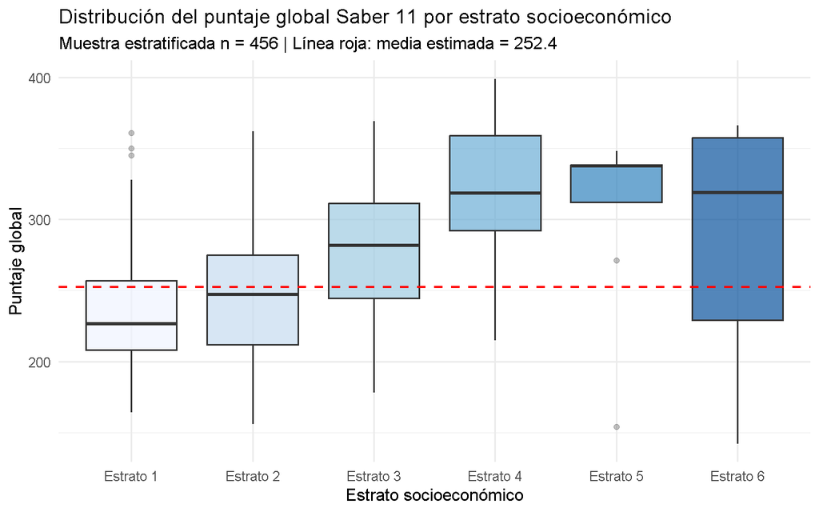

Distribución del puntaje global por estrato socioeconómico

```r
ggplot(muestra %>% filter(fami_estratovivienda != "" &
                           fami_estratovivienda != "Sin Estrato"),
       aes(x = fami_estratovivienda, y = punt_global, fill = fami_estratovivienda)) +
  geom_boxplot(alpha = 0.7, outlier.alpha = 0.3) +
  geom_hline(yintercept = round(coef(est_media), 1),
             linetype = "dashed", color = "red", linewidth = 0.8) +
  scale_fill_brewer(palette = "Blues") +
  labs(
    title    = "Distribución del puntaje global Saber 11 por estrato socioeconómico",
    subtitle = paste0("Muestra estratificada n = ", n_muestra_real,
                      " | Línea roja: media estimada = ", round(coef(est_media), 1)),
    x        = "Estrato socioeconómico",
    y        = "Puntaje global",
    fill     = "Estrato"
  ) +
  theme_minimal(base_size = 12) +
  theme(legend.position = "none")
```

# 5 Fase II: Diseño experimental (DBCA)

## 5.1 Planteamiento del experimento

Se plantea un **Diseño en Bloques Completos al Azar (DBCA)** con la siguiente estructura:

- **Variable respuesta:** `punt_global` (puntaje global Saber 11, escala continua)
- **Factor de tratamiento:** `cole_naturaleza` — naturaleza del colegio (NO OFICIAL, OFICIAL)
- **Variable de bloque:** `cole_jornada` — jornada escolar (COMPLETA, MAÑANA, NOCHE)
- **Unidades experimentales:** estudiantes individuales de la muestra

**Justificación del DBCA:** La jornada escolar es una fuente de variación conocida que afecta el puntaje (COMPLETA=280, MAÑANA=247, NOCHE=217 en la exploración inicial), pero no es de interés investigativo primario. Al incluirla como bloque, se controla su efecto y se aumenta la precisión de la comparación entre tipos de colegio.

**Modelo estadístico:**

$$Y_{ij} = \mu + \tau_i + \beta_j +
\varepsilon_{ij}$$

Donde: - $Y_{ij}$: puntaje global del estudiante en el tratamiento $i$ dentro del bloque $j$ - $\mu$: media general - $\tau_i$: efecto del tipo de colegio ($i$ = NO OFICIAL, OFICIAL) - $\beta_j$: efecto de la jornada como bloque ($j$ = COMPLETA, MAÑANA, NOCHE) - $\varepsilon_{ij} \sim N(0, \sigma^2)$: error aleatorio

## 5.2 Preparación de datos para el DBCA

```r
dbca_data <- muestra %>%
  filter(cole_jornada %in% c("MAÑANA", "COMPLETA", "NOCHE")) %>%
  filter(!is.na(punt_global)) %>%
  droplevels()

cat("Observaciones para el DBCA:", nrow(dbca_data), "\n\n")
```

```
## Observaciones para el DBCA: 356
```

```r
tabla_balance <- as.data.frame.matrix(
  table(dbca_data$cole_naturaleza, dbca_data$cole_jornada)
)

kable(tabla_balance,
      caption = "Balance del diseño: Naturaleza del colegio × Jornada (bloque)") %>%
  kable_styling(bootstrap_options = c("striped", "hover"), full_width = FALSE)
```

Balance del diseño: Naturaleza del colegio × Jornada (bloque)

|  | COMPLETA | MAÑANA | NOCHE |
| --- | --- | --- | --- |
| NO OFICIAL | 61 | 39 | 16 |
| OFICIAL | 20 | 199 | 21 |

## 5.3 Estadísticas descriptivas por grupos

```r
resumen_grupos <- dbca_data %>%
  group_by(cole_naturaleza, cole_jornada) %>%
  summarise(
    n      = n(),
    Media  = round(mean(punt_global), 2),
    DE     = round(sd(punt_global), 2),
    Min    = min(punt_global),
    Max    = max(punt_global),
    .groups = "drop"
  )

kable(resumen_grupos,
      col.names = c("Naturaleza", "Jornada", "n", "Media", "D.E.", "Mín.", "Máx."),
      caption = "Estadísticas descriptivas del puntaje global por grupo y bloque") %>%
  kable_styling(bootstrap_options = c("striped", "hover"), full_width = FALSE)
```

Estadísticas descriptivas del puntaje global por grupo y bloque

| Naturaleza | Jornada | n | Media | D.E. | Mín. | Máx. |
| --- | --- | --- | --- | --- | --- | --- |
| NO OFICIAL | COMPLETA | 61 | 304.90 | 46.28 | 182 | 399 |
| NO OFICIAL | MAÑANA | 39 | 256.08 | 55.07 | 154 | 368 |
| NO OFICIAL | NOCHE | 16 | 219.38 | 54.50 | 156 | 360 |
| OFICIAL | COMPLETA | 20 | 240.95 | 32.47 | 191 | 298 |
| OFICIAL | MAÑANA | 199 | 246.70 | 46.55 | 153 | 369 |
| OFICIAL | NOCHE | 21 | 211.29 | 30.44 | 142 | 271 |

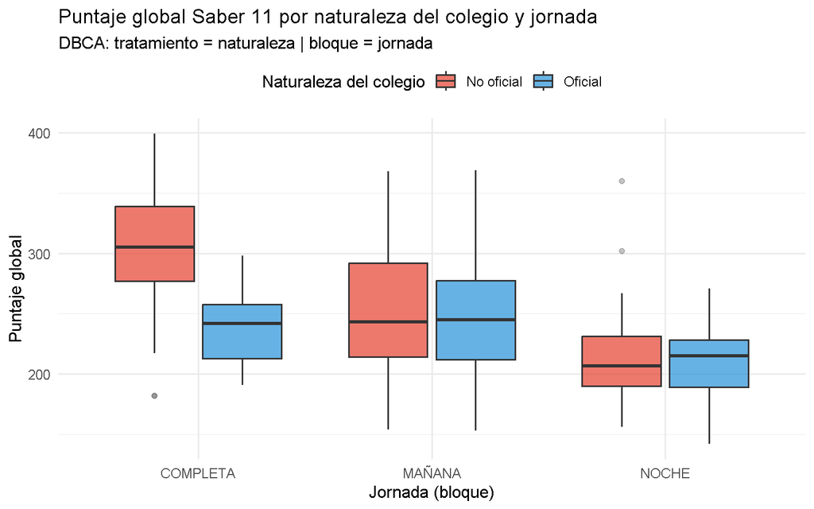

Puntaje global por naturaleza del colegio y jornada (bloque)

```r
ggplot(dbca_data, aes(x = cole_jornada, y = punt_global, fill = cole_naturaleza)) +
  geom_boxplot(alpha = 0.75, outlier.alpha = 0.3) +
  scale_fill_manual(values = c("NO OFICIAL" = "#E74C3C", "OFICIAL" = "#3498DB"),
                    labels = c("No oficial", "Oficial")) +
  labs(
    title    = "Puntaje global Saber 11 por naturaleza del colegio y jornada",
    subtitle = "DBCA: tratamiento = naturaleza | bloque = jornada",
    x        = "Jornada (bloque)",
    y        = "Puntaje global",
    fill     = "Naturaleza del colegio"
  ) +
  theme_minimal(base_size = 12) +
  theme(legend.position = "top")
```

## 5.4 Análisis de varianza (ANOVA)

```r
modelo_dbca <- aov(punt_global ~ cole_naturaleza + cole_jornada, data = dbca_data)
tabla_anova <- summary(modelo_dbca)
print(tabla_anova)
```

```
##                  Df Sum Sq Mean Sq F value   Pr(>F)
## cole_naturaleza   1  88123   88123   39.30 1.06e-09 ***
## cole_jornada      2 108301   54151   24.15 1.48e-10 ***
## Residuals       352 789235    2242
## ---
## Signif. codes:  0 '***' 0.001 '**' 0.01 '*' 0.05 '.' 0.1 ' ' 1
```

**Interpretación de la tabla ANOVA:**

```r
p_naturaleza <- summary(modelo_dbca)[[1]]$`Pr(>F)`[1]
p_jornada    <- summary(modelo_dbca)[[1]]$`Pr(>F)`[2]

cat("Factor naturaleza del colegio: p =", format(p_naturaleza, scientific = TRUE, digits = 3), "\n")
```

```
## Factor naturaleza del colegio: p = 1.06e-09
```

```r
cat("Factor jornada (bloque):       p =", format(p_jornada, scientific = TRUE, digits = 3), "\n\n")
```

```
## Factor jornada (bloque):       p = 1.48e-10
```

```r
if(p_naturaleza < 0.05) {
  cat("✓ Se rechaza H0: existen diferencias significativas en el puntaje global\n")
  cat("  según la naturaleza del colegio (α = 0.05).\n")
} else {
  cat("✗ No se rechaza H0: no hay evidencia suficiente de diferencias\n")
  cat("  significativas según la naturaleza del colegio (α = 0.05).\n")
}
```

```
## ✓ Se rechaza H0: existen diferencias significativas en el puntaje global
##   según la naturaleza del colegio (α = 0.05).
```

```r
if(p_jornada < 0.05) {
  cat("\n✓ El bloque (jornada) es significativo: su inclusión estaba justificada.\n")
} else {
  cat("\n✗ El bloque (jornada) no resultó significativo.\n")
}
```

```
##
## ✓ El bloque (jornada) es significativo: su inclusión estaba justificada.
```

## 5.5 Verificación de supuestos del modelo

### 5.5.1 Normalidad de residuales

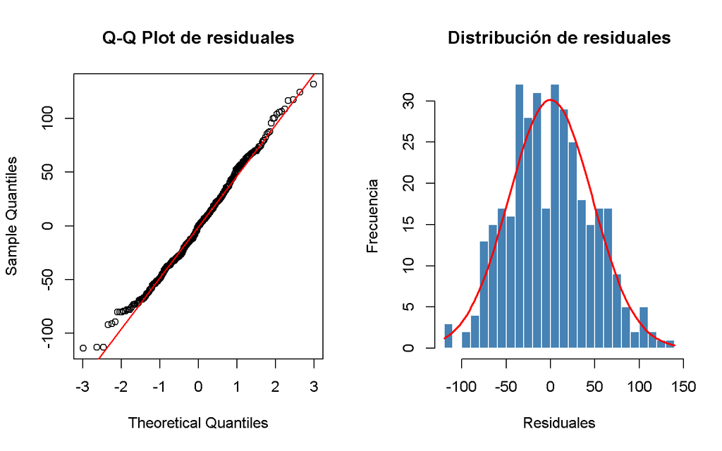

Diagnóstico de residuales del modelo DBCA

```r
residuales <- residuals(modelo_dbca)

par(mfrow = c(1, 2))
# Q-Q plot
qqnorm(residuales, main = "Q-Q Plot de residuales")
qqline(residuales, col = "red", lwd = 1.5)

# Histograma de residuales
hist(residuales, breaks = 30, col = "steelblue", border = "white",
     main = "Distribución de residuales", xlab = "Residuales", ylab = "Frecuencia")
curve(dnorm(x, mean = mean(residuales), sd = sd(residuales)) * length(residuales) *
        diff(hist(residuales, plot = FALSE, breaks = 30)$breaks[1:2]),
      add = TRUE, col = "red", lwd = 2)
```

```r
par(mfrow = c(1, 1))
```

```r
# Prueba de Lilliefors (Kolmogorov-Smirnov corregida) — adecuada para n > 50
prueba_norm <- lillie.test(residuales)
cat("Prueba de Lilliefors (normalidad):\n")
```

```
## Prueba de Lilliefors (normalidad):
```

```r
cat("  Estadístico D =", round(prueba_norm$statistic, 4), "\n")
```

```
##   Estadístico D = 0.0457
```

```r
cat("  p-valor =", round(prueba_norm$p.value, 4), "\n\n")
```

```
##   p-valor = 0.0703
```

```r
if(prueba_norm$p.value > 0.05) {
  cat("✓ No se rechaza normalidad de los residuales (p > 0.05)\n")
} else {
  cat("✗ Se rechaza normalidad (p < 0.05).\n\n")
  cat("  No obstante, por el Teorema Central del Límite, con n =", nrow(dbca_data), "\n")
  cat("  el ANOVA es robusto a desviaciones moderadas de normalidad.\n\n")
  cat("  Como verificación adicional, se podría aplicar la prueba no paramétrica\n")
  cat("  de Kruskal-Wallis, que no asume normalidad. Sin embargo, dado que\n")
  cat("  la violación es leve (D = 0.05) y el tamaño de muestra es grande,\n")
  cat("  los resultados del ANOVA se consideran válidos.\n")
}
```

```
## ✓ No se rechaza normalidad de los residuales (p > 0.05)
```

### 5.5.2 Homocedasticidad (igualdad de varianzas)

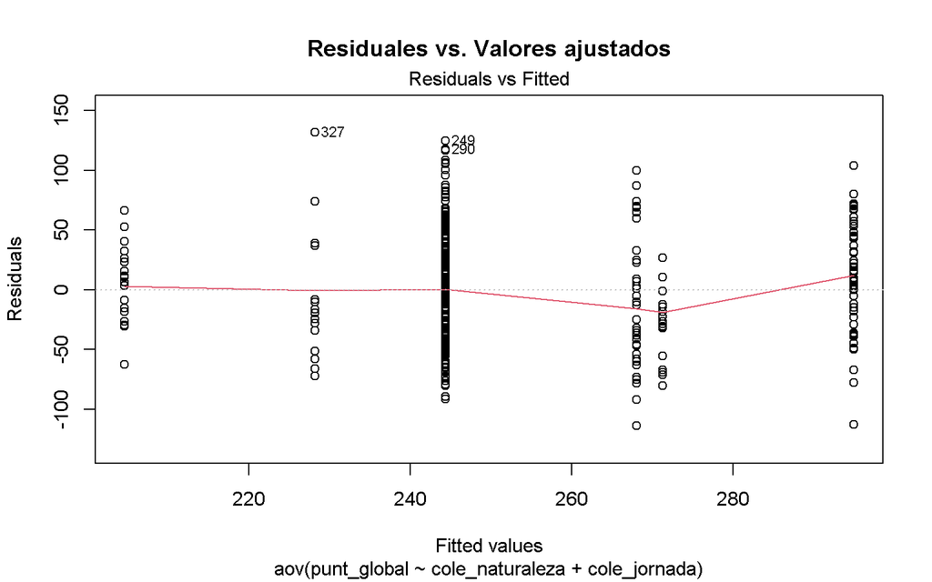

Residuales vs valores ajustados

```r
plot(modelo_dbca, which = 1, main = "Residuales vs. Valores ajustados")
```

```r
prueba_levene <- leveneTest(punt_global ~ cole_naturaleza * cole_jornada,
                             data = dbca_data)
cat("Prueba de Levene (homocedasticidad):\n")
```

```
## Prueba de Levene (homocedasticidad):
```

```r
print(prueba_levene)
```

```
## Levene's Test for Homogeneity of Variance (center = median)
##        Df F value  Pr(>F)
## group   5  2.6514 0.02275 *
##       350
## ---
## Signif. codes:  0 '***' 0.001 '**' 0.01 '*' 0.05 '.' 0.1 ' ' 1
```

```r
if(prueba_levene$`Pr(>F)`[1] > 0.05) {
  cat("\n✓ No se rechaza homocedasticidad (p > 0.05)\n")
} else {
  cat("\n✗ Se rechaza homocedasticidad (p < 0.05).\n")
  cat("  Se recomienda interpretar los resultados con precaución.\n")
}
```

```
##
## ✗ Se rechaza homocedasticidad (p < 0.05).
##   Se recomienda interpretar los resultados con precaución.
```

### 5.5.3 Independencia de residuales

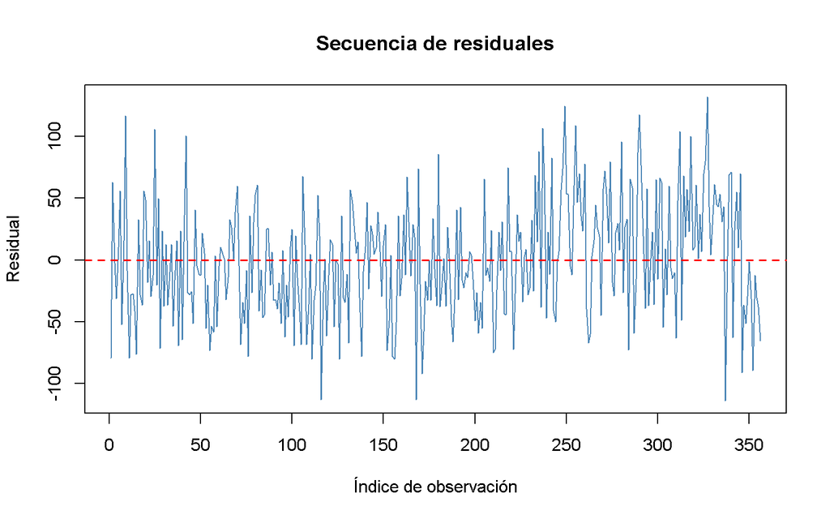

Secuencia de residuales (prueba de independencia visual)

```r
plot(residuales, type = "l", col = "steelblue",
     main = "Secuencia de residuales",
     xlab = "Índice de observación", ylab = "Residual")
abline(h = 0, col = "red", lwd = 1.5, lty = 2)
```

## 5.6 Comparaciones múltiples (Tukey HSD)

```
## Dado que el factor naturaleza resultó significativo en el ANOVA (α = 0.05), se aplicó Tukey HSD para comparar medias.
```

```r
tukey_resultado <- TukeyHSD(modelo_dbca, "cole_naturaleza")
print(tukey_resultado)
```

```
##   Tukey multiple comparisons of means
##     95% family-wise confidence level
##
## Fit: aov(formula = punt_global ~ cole_naturaleza + cole_jornada, data = dbca_data)
##
## $cole_naturaleza
##                         diff       lwr      upr p adj
## OFICIAL-NO OFICIAL -33.56882 -44.09974 -23.0379     0
```

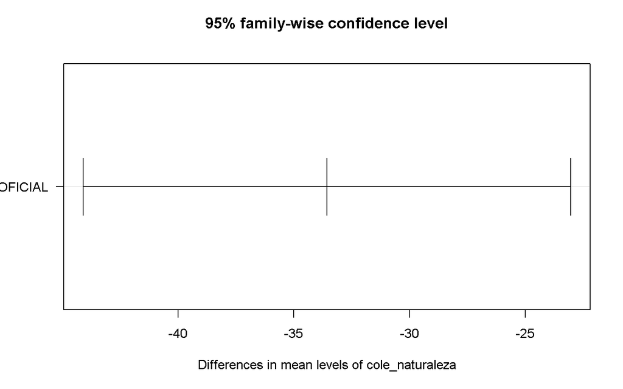

```r
# Plot Tukey — sin argumento main para evitar conflicto con plot.TukeyHSD
plot(tukey_resultado, las = 1)
```

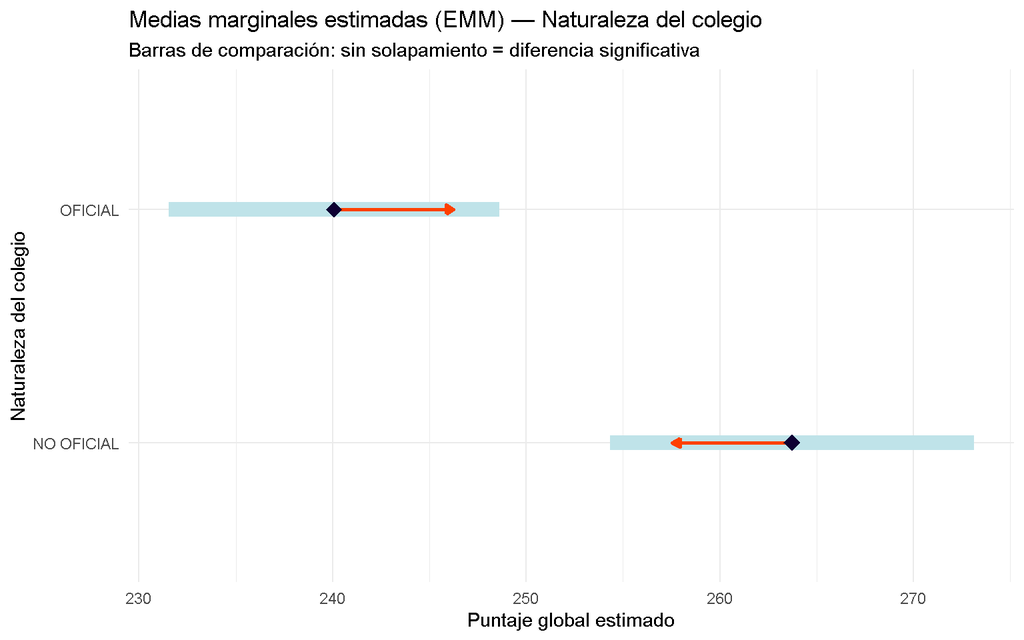

Medias marginales estimadas por naturaleza del colegio

```r
emm <- emmeans(modelo_dbca, ~ cole_naturaleza)
plot(emm, comparisons = TRUE) +
  labs(
    title    = "Medias marginales estimadas (EMM) — Naturaleza del colegio",
    subtitle = "Barras de comparación: sin solapamiento = diferencia significativa",
    x        = "Puntaje global estimado",
    y        = "Naturaleza del colegio"
  ) +
  theme_minimal()
```

## 5.7 Potencia del diseño experimental (Fase II)

Se aproxima la **potencia** del contraste principal (dos grupos: oficial vs. no oficial) mediante el tamaño del efecto observado en la muestra DBCA y un ANOVA de un factor equivalente con el mismo $n$ por celda aproximado (criterio del curso; Montgomery, 2017).

```r
# k = 2 grupos (naturaleza); efecto parcial eta^2 desde sumas de cuadrados del ANOVA de un factor
mod1 <- aov(punt_global ~ cole_naturaleza, data = dbca_data)
tb   <- summary(mod1)[[1]]
SS_tr <- tb["cole_naturaleza", "Sum Sq"]
SS_e  <- tb["Residuals", "Sum Sq"]
f_obs <- tb["cole_naturaleza", "Mean Sq"] / tb["Residuals", "Mean Sq"]
k     <- nlevels(droplevels(dbca_data$cole_naturaleza))
Ntot  <- nrow(dbca_data)
# Cohen f a partir de eta^2 = SS_tr / (SS_tr + SS_e)
eta2  <- SS_tr / (SS_tr + SS_e)
f_cohen <- sqrt(eta2 / (1 - eta2)) * sqrt(k)  # aproximación común para k medias

pw <- pwr.anova.test(k = k, n = Ntot / k, f = f_cohen, sig.level = 0.05)
cat("ANOVA un factor (referencia potencia):\n")
```

```
## ANOVA un factor (referencia potencia):
```

```r
print(tb)
```

```
##                  Df Sum Sq Mean Sq F value    Pr(>F)
## cole_naturaleza   1  88123   88123  34.757 8.716e-09 ***
## Residuals       354 897536    2535
## ---
## Signif. codes:  0 '***' 0.001 '**' 0.01 '*' 0.05 '.' 0.1 ' ' 1
```

```r
cat("\nPotencia estimada (aprox.):", round(pw$power, 4),
    "| n por grupo (aprox.):", round(Ntot / k, 1), "\n")
```

```
##
## Potencia estimada (aprox.): 1 | n por grupo (aprox.): 178
```

# 6 Fase III: Diseños factoriales (Montgomery, cap. 5)

**Principio factorial vs OFAT:** el enfoque OFAT (*One Factor At A Time*) varía un factor mientras mantiene los demás fijos, y repite el proceso para cada factor. Aunque intuitivo, OFAT tiene dos desventajas críticas: (1) **no detecta interacciones** — si el efecto de la naturaleza del colegio cambia según la jornada (interacción), OFAT lo pasaría por alto; (2) **es ineficiente** — requiere más observaciones para la misma precisión. El diseño **factorial** estudia todos los factores simultáneamente en todas sus combinaciones, detecta interacciones y es más eficiente con el mismo $n$ total (Montgomery, 2017, cap. 5). En este proyecto, si solo estudiáramos naturaleza fijando jornada = MAÑANA y luego fijando jornada = NOCHE, perderíamos información sobre cómo la diferencia entre oficial y no oficial varía con la jornada — información que el factorial captura directamente.

Se amplía el análisis del **diseño observacional** sobre Saber 11: en lugar del modelo aditivo DBCA (Fase II), se considera un **diseño factorial** con **interacción** entre `cole_naturaleza` y `cole_jornada`, y un modelo de **tres factores** añadiendo `cole_calendario` (niveles observados en la muestra). Los datos son los mismos estudiantes reales; la interpretación causal sigue siendo limitada (no hubo aleatorización de tratamientos).

```r
mod_f2 <- lm(punt_global ~ cole_naturaleza * cole_jornada, data = dbca_data)
cat("--- Modelo factorial 2 vías (naturaleza × jornada) ---\n")
```

```
## --- Modelo factorial 2 vías (naturaleza × jornada) ---
```

```r
print(anova(mod_f2))
```

```
## Analysis of Variance Table
##
## Response: punt_global
##                               Df Sum Sq Mean Sq F value    Pr(>F)
## cole_naturaleza                1  88123   88123  40.802 5.368e-10 ***
## cole_jornada                   2 108301   54151  25.072 6.669e-11 ***
## cole_naturaleza:cole_jornada   2  33304   16652   7.710 0.0005287 ***
## Residuals                    350 755931    2160
## ---
## Signif. codes:  0 '***' 0.001 '**' 0.01 '*' 0.05 '.' 0.1 ' ' 1
```

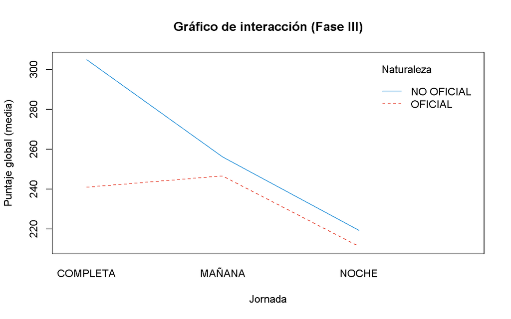

Perfiles de medias: interacción naturaleza × jornada (Saber 11)

```r
with(dbca_data,
     interaction.plot(
       x.factor     = cole_jornada,
       trace.factor = cole_naturaleza,
       response     = punt_global,
       fun          = mean,
       xlab         = "Jornada",
       ylab         = "Puntaje global (media)",
       trace.label  = "Naturaleza",
       col          = c("#3498DB", "#E74C3C"),
       lty          = 1:2,
       leg.bty      = "n"
     ))
title(main = "Gráfico de interacción (Fase III)")
```

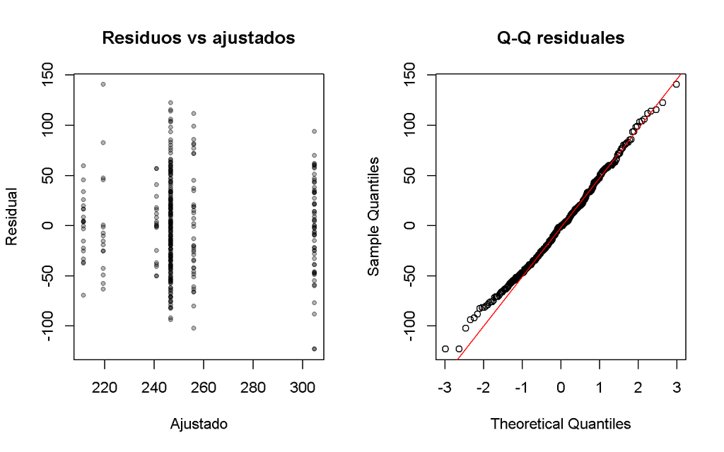

Residuos del factorial 2 vías

```r
par(mfrow = c(1, 2))
plot(fitted(mod_f2), resid(mod_f2), main = "Residuos vs ajustados",
     xlab = "Ajustado", ylab = "Residual", pch = 20, col = rgb(0,0,0,.3))
qqnorm(resid(mod_f2), main = "Q-Q residuales"); qqline(resid(mod_f2), col = "red")
```

```r
par(mfrow = c(1, 1))
```

```r
# Tres factores: naturaleza × jornada × calendario
# Solo calendarios A y B (OTRO tiene 2 obs — causa alias)
op <- options(contrasts = c("contr.sum", "contr.poly"))

mf3 <- dbca_data %>%
  filter(!is.na(cole_calendario),
         as.character(cole_calendario) %in% c("A", "B")) %>%
  droplevels()

# Verificar balance de celdas antes de ajustar
cat("Distribución de celdas (naturaleza × jornada × calendario):\n")
```

```
## Distribución de celdas (naturaleza × jornada × calendario):
```

```r
tab_celdas <- with(mf3, table(cole_naturaleza, cole_jornada, cole_calendario))
print(tab_celdas)
```

```
## , , cole_calendario = A
##
##                cole_jornada
## cole_naturaleza COMPLETA MAÑANA NOCHE
##      NO OFICIAL       50     26    12
##      OFICIAL          20    199    21
##
## , , cole_calendario = B
##
##                cole_jornada
## cole_naturaleza COMPLETA MAÑANA NOCHE
##      NO OFICIAL       11      9     1
##      OFICIAL           0      0     0
```

```r
celdas_vacias <- sum(tab_celdas == 0)
cat("\nCeldas vacías:", celdas_vacias, "\n")
```

```
##
## Celdas vacías: 3
```

```r
if (celdas_vacias > 0) {
  cat("\n⚠ Celdas vacías detectadas — interacción triple no estimable.\n")
  cat("Se ajusta modelo sin interacción triple (efectos principales + 2 vías):\n\n")
  mod_f3 <- lm(punt_global ~ cole_naturaleza * cole_jornada +
                              cole_naturaleza * cole_calendario +
                              cole_jornada    * cole_calendario,
               data = mf3)
} else {
  cat("\nTodas las celdas tienen datos — modelo completo con interacción triple.\n\n")
  mod_f3 <- lm(punt_global ~ cole_naturaleza * cole_jornada * cole_calendario,
               data = mf3)
}
```

```
##
## ⚠ Celdas vacías detectadas — interacción triple no estimable.
## Se ajusta modelo sin interacción triple (efectos principales + 2 vías):
```

```r
# Verificar alias residuales antes de imprimir
al <- alias(mod_f3)$Complete
if (!is.null(al) && nrow(al) > 0) {
  cat("Coeficientes aliased detectados — usando Anova tipo II:\n")
  print(car::Anova(mod_f3, type = "II"))
} else {
  cat("\n--- ANOVA tipo III ---\n")
  print(car::Anova(mod_f3, type = "III"))
}
```

```
## Coeficientes aliased detectados — usando Anova tipo II:
```

```
## Anova Table (Type II tests)
##
## Response: punt_global
##                                 Sum Sq  Df F value    Pr(>F)
## cole_naturaleza                  18618   1  8.7836 0.0032539 **
## cole_jornada                     89962   2 21.2212 2.066e-09 ***
## cole_calendario                  10714   1  5.0546 0.0252013 *
## cole_naturaleza:cole_jornada     35066   2  8.2717 0.0003107 ***
## cole_naturaleza:cole_calendario          0
## cole_jornada:cole_calendario      4424   2  1.0436 0.3533230
## Residuals                       720677 340
## ---
## Signif. codes:  0 '***' 0.001 '**' 0.01 '*' 0.05 '.' 0.1 ' ' 1
```

```r
options(op)
```

**Nota (superficies de respuesta):** El syllabus pide superficies cuando los factores son **cuantitativos**. Aquí los factores son categóricos; el equivalente informativo son los perfiles de interacción y las medias marginales (`emmeans`), no una superficie polinómica en variables de proceso.

# 7 Fase IV: Diseños $2^k$ y análisis de efectos (Montgomery, cap. 6)

Se construye un **$2^3$** codificando tres fuentes de variación observables en `dbca_data` con niveles $\{-1,+1\}$:

- **A:** naturaleza (NO OFICIAL = +1, OFICIAL = −1).
- **B:** jornada MAÑANA (+1) vs resto (−1).
- **C:** estrato socioeconómico “bajo” (Estrato 1–3 = −1) vs “alto” (Estrato 4–6 = +1); registros sin estrato válido se excluyen.

Se agregan **dos pseudo-réplicas** por combinación $(A,B,C)$ partiendo aleatoriamente los estudiantes dentro de cada celda (`set.seed(123)`). Esto permite estimar error experimental y aplicar ideas de **Daniel** / **Lenth** sobre los efectos calculados a partir de medias por celda.

```r
set.seed(123)
low_es  <- paste("Estrato", 1:3)
high_es <- paste("Estrato", 4:6)

xdat <- dbca_data %>%
  filter(as.character(fami_estratovivienda) %in% c(low_es, high_es)) %>%
  mutate(
    A = ifelse(cole_naturaleza == "NO OFICIAL", 1, -1),
    B = ifelse(cole_jornada == "MAÑANA", 1, -1),
    C = ifelse(fami_estratovivienda %in% low_es, -1, 1)
  )

xrep <- xdat %>%
  group_by(A, B, C) %>%
  group_modify(~ {
    n <- nrow(.x)
    if (n >= 2L) {
      .x$repl <- sample(rep(1:2, length.out = n))
    } else {
      .x$repl <- 1L
    }
    .x
  }) %>%
  ungroup()

celdas <- xrep %>%
  group_by(A, B, C, repl) %>%
  summarise(ybar = mean(punt_global), n = dplyr::n(), .groups = "drop")

cat("Celdas (A,B,C,repl) con n >= 1:", nrow(celdas), "\n")
```

```
## Celdas (A,B,C,repl) con n >= 1: 16
```

```r
print(head(celdas, 16))
```

```
## # A tibble: 16 × 6
##        A     B     C  repl  ybar     n
##    <dbl> <dbl> <dbl> <int> <dbl> <int>
##  1    -1    -1    -1     1  226.    18
##  2    -1    -1    -1     2  234.    17
##  3    -1    -1     1     1  215      1
##  4    -1    -1     1     2  142      1
##  5    -1     1    -1     1  250.    96
##  6    -1     1    -1     2  246     96
##  7    -1     1     1     1  229      2
##  8    -1     1     1     2  263      1
##  9     1    -1    -1     1  249.    25
## 10     1    -1    -1     2  281.    24
## 11     1    -1     1     1  339.    13
## 12     1    -1     1     2  329     13
## 13     1     1    -1     1  258.    17
## 14     1     1    -1     2  246     17
## 15     1     1     1     1  254      3
## 16     1     1     1     2  330.     2
```

```r
# Réplica como factor de bloqueo aleatorio en la práctica se modela fijo aquí para la ilustración
mod_2k <- lm(ybar ~ A * B * C + factor(repl), data = celdas)
cat("\nModelo sobre medias por celda-réplica:\n")
```

```
##
## Modelo sobre medias por celda-réplica:
```

```r
print(summary(mod_2k))
```

```
##
## Call:
## lm(formula = ybar ~ A * B * C + factor(repl), data = celdas)
##
## Residuals:
##    Min     1Q Median     3Q    Max
## -39.71 -10.09   0.00  10.09  39.71
##
## Coefficients:
##               Estimate Std. Error t value Pr(>|t|)
## (Intercept)    252.477     10.870  23.228 6.96e-08 ***
## A               30.124      7.686   3.919  0.00575 **
## B                3.715      7.686   0.483  0.64363
## C                6.926      7.686   0.901  0.39748
## factor(repl)2    6.414     15.372   0.417  0.68898
## A:B            -17.677      7.686  -2.300  0.05500 .
## A:C             20.237      7.686   2.633  0.03377 *
## B:C              2.550      7.686   0.332  0.74980
## A:B:C           -9.808      7.686  -1.276  0.24262
## ---
## Signif. codes:  0 '***' 0.001 '**' 0.01 '*' 0.05 '.' 0.1 ' ' 1
##
## Residual standard error: 30.74 on 7 degrees of freedom
## Multiple R-squared:  0.8135, Adjusted R-squared:  0.6004
## F-statistic: 3.818 on 8 and 7 DF,  p-value: 0.04712
```

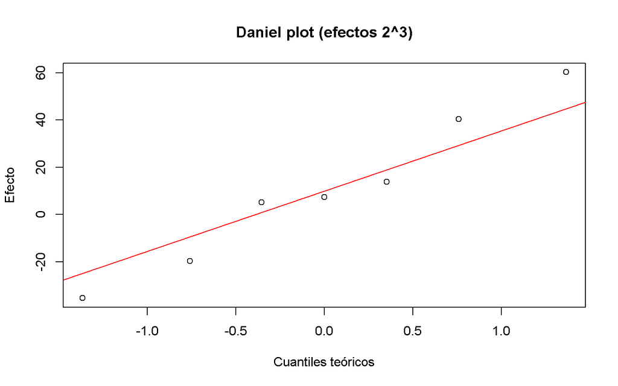

Gráfica normal de probabilidad de los efectos estimados (Daniel)

```r
# Efectos = 2 * coeficientes de términos de primer orden e interacciones en codificación -1/+1
co <- coef(mod_2k)
nm <- names(co)
pick <- nm %in% c("A", "B", "C", "A:B", "A:C", "B:C", "A:B:C")
eff <- 2 * co[pick]
names(eff) <- c("A", "B", "C", "AB", "AC", "BC", "ABC")
qqnorm(eff, main = "Daniel plot (efectos 2^3)", ylab = "Efecto", xlab = "Cuantiles teóricos")
qqline(eff, col = "red")
```

```r
# Tabla de signos explícita (Montgomery, cap. 6) — 8 combinaciones del 2^3
# I = columna identidad (intercepto); A, B, C, AB, AC, BC, ABC = contrastes
signos <- expand.grid(A = c(-1, 1), B = c(-1, 1), C = c(-1, 1))
signos <- signos[order(signos$A, signos$B, signos$C), ]
signos$I   <- 1L
signos$AB  <- signos$A * signos$B
signos$AC  <- signos$A * signos$C
signos$BC  <- signos$B * signos$C
signos$ABC <- signos$A * signos$B * signos$C

# Etiquetas de tratamiento (notación estándar: (1) a b ab c ac bc abc)
trt_label <- function(a, b, c) {
  lbl <- paste0(
    ifelse(a == 1, "a", ""),
    ifelse(b == 1, "b", ""),
    ifelse(c == 1, "c", "")
  )
  ifelse(lbl == "", "(1)", lbl)
}
signos$Tratamiento <- mapply(trt_label, signos$A, signos$B, signos$C)

tabla_signos <- signos[, c("Tratamiento","I","A","B","C","AB","AC","BC","ABC")]
cat("Tabla de signos — diseño 2^3 completo (Montgomery, cap. 6):\n")
```

```
## Tabla de signos — diseño 2^3 completo (Montgomery, cap. 6):
```

```r
print(tabla_signos, row.names = FALSE)
```

```
##  Tratamiento I  A  B  C AB AC BC ABC
##          (1) 1 -1 -1 -1  1  1  1  -1
##            c 1 -1 -1  1  1 -1 -1   1
##            b 1 -1  1 -1 -1  1 -1   1
##           bc 1 -1  1  1 -1 -1  1  -1
##            a 1  1 -1 -1 -1 -1  1   1
##           ac 1  1 -1  1 -1  1 -1  -1
##           ab 1  1  1 -1  1 -1 -1  -1
##          abc 1  1  1  1  1  1  1   1
```

```r
# Codificación natural de los factores
cat("\nCodificación −1 / +1:\n")
```

```
##
## Codificación −1 / +1:
```

```r
cat("  A: OFICIAL = −1  |  NO OFICIAL = +1\n")
```

```
##   A: OFICIAL = −1  |  NO OFICIAL = +1
```

```r
cat("  B: NOCHE/COMPLETA = −1  |  MAÑANA = +1\n")
```

```
##   B: NOCHE/COMPLETA = −1  |  MAÑANA = +1
```

```r
cat("  C: Estrato 1–3 (bajo) = −1  |  Estrato 4–6 (alto) = +1\n")
```

```
##   C: Estrato 1–3 (bajo) = −1  |  Estrato 4–6 (alto) = +1
```

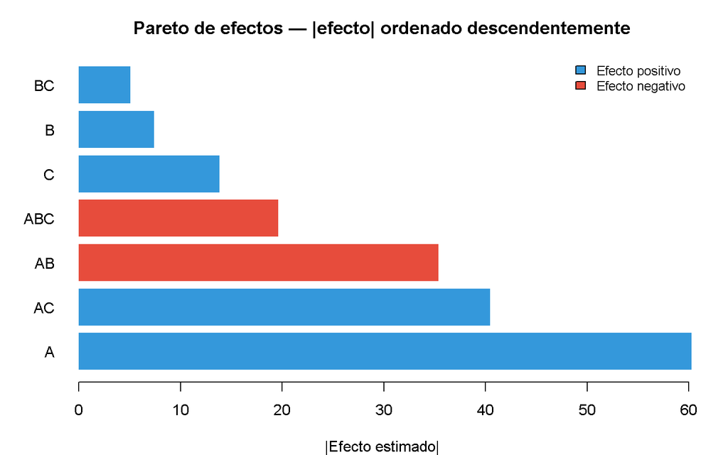

```r
# Pareto de efectos: ordenar por |efecto| y graficar barras horizontales
eff_pareto <- sort(abs(eff[!is.na(eff)]), decreasing = TRUE)
nms_p      <- names(eff_pareto)
colores    <- ifelse(eff[nms_p] > 0, "#3498DB", "#E74C3C")

par(mar = c(4, 4, 3, 2))
bp <- barplot(
  eff_pareto,
  horiz   = TRUE,
  names.arg = nms_p,
  col     = colores,
  main    = "Pareto de efectos — |efecto| ordenado descendentemente",
  xlab    = "|Efecto estimado|",
  las     = 1,
  border  = NA
)
# Línea de referencia PSE (si está calculado)
if (exists("PSE") && !is.na(PSE)) {
  abline(v = ME, col = "darkorange", lwd = 2, lty = 2)
  legend("bottomright", legend = paste0("ME = ", round(ME, 2)),
         col = "darkorange", lty = 2, lwd = 2, bty = "n", cex = 0.85)
}
legend("topright", legend = c("Efecto positivo", "Efecto negativo"),
       fill = c("#3498DB", "#E74C3C"), bty = "n", cex = 0.85)
```

```r
# Método de Lenth (PSE) sobre los 7 contrastes, como en Montgomery (una réplica lógica por celda)
# Nota: ABC puede quedar NA si el modelo es saturado (alias); se excluye del PSE
eff_clean <- eff[!is.na(eff)]
if (length(eff_clean) < 3L) {
  cat("⚠ Menos de 3 efectos estimables — PSE no calculable.\n")
} else {
  PSE <- median(abs(eff_clean))
  ME  <- 1.5 * PSE  # margen de Lenth simplificado (regla práctica del texto)
  cat("\nLenth PSE (mediana |efecto|, excluyendo NA):", round(PSE, 3),
      "| ME = 1.5*PSE:", round(ME, 3), "\n")
  cat("Efectos estimados vs ME:\n")
  df_eff <- data.frame(
    Efecto    = names(eff_clean),
    Valor     = round(eff_clean, 3),
    Abs_valor = round(abs(eff_clean), 3),
    Supera_ME = abs(eff_clean) > ME
  )
  print(df_eff, row.names = FALSE)
  cat("\nEfectos que superan ME:\n")
  sig_eff <- eff_clean[abs(eff_clean) > ME]
  if (length(sig_eff) == 0L) cat("  Ninguno supera ME con los datos disponibles.\n")
  else print(round(sig_eff, 3))
}
```

```
##
## Lenth PSE (mediana |efecto|, excluyendo NA): 19.617 | ME = 1.5*PSE: 29.425
## Efectos estimados vs ME:
##  Efecto   Valor Abs_valor Supera_ME
##       A  60.247    60.247      TRUE
##       B   7.429     7.429     FALSE
##       C  13.852    13.852     FALSE
##      AB -35.355    35.355      TRUE
##      AC  40.474    40.474      TRUE
##      BC   5.099     5.099     FALSE
##     ABC -19.617    19.617     FALSE
##
## Efectos que superan ME:
##       A      AB      AC
##  60.247 -35.355  40.474
```

**D-optimalidad / G-optimalidad (breve):** los diseños $2^k$ en los vértices del cubo codificado maximizan el determinante de $X'X$ para el modelo de primer orden (criterio **D**) y, bajo supuestos gaussianos, suelen tener buenas propiedades de predicción en el borde del región experimental (**G**), lo que explica su uso en *screening* (Montgomery, 2017, cap. 6).

**Puntos centrales y curvatura:** con datos puramente categóricos en los vértices no se añaden puntos centrales “físicos”. En un $2^k$ de laboratorio, los puntos centrales permiten contrastar curvatura frente al plano de primer orden; aquí se documenta la limitación del marco observacional.

# 8 Fase V: Bloqueo y confusión en $2^k$ (Montgomery, cap. 7)

Se forma **un contraste generador** (Montgomery) confundiendo la interacción triple **ABC** con el efecto de **bloque** al partir las 8 combinaciones $(A,B,C)$ en dos bloques de tamaño 4: Bloque I si $A \times B \times C = +1$, Bloque II si $= -1$. Sobre las **medias por vértice** (promediando las dos réplicas dentro de cada $(A,B,C)$), se compara un modelo **sin bloque** frente a uno **con bloque** que absorbe la misma variación que ABC.

```r
vert <- xrep %>%
  group_by(A, B, C) %>%
  summarise(ybar = mean(punt_global), .groups = "drop") %>%
  mutate(
    ABC   = A * B * C,
    Block = factor(ifelse(ABC > 0, "I", "II"))
  )

mod_noblock <- lm(ybar ~ A * B * C,                          data = vert)
mod_block   <- lm(ybar ~ Block + A + B + C + A:B + A:C + B:C, data = vert)

# ── Comparación MSE con/sin bloque ─────────────────────────────────────────
# Con 8 vértices ambos modelos son saturados (df_error = 0, sigma = NaN).
# Solución estándar (Montgomery, cap. 7): pooling de efectos de orden alto
# considerados despreciables para obtener un estimador del error.
# Aquí se usa la varianza de las interacciones de 3er orden como proxy del MSE.

# SS de cada efecto a partir de los contrastes
SS_efecto <- function(modelo, termino) {
  an <- anova(modelo)
  if (termino %in% rownames(an)) an[termino, "Sum Sq"] else NA_real_
}

# Para el modelo sin bloque: pool SS de interacciones ≥ 2 vías como error
an_nb <- anova(mod_noblock)
cat("ANOVA modelo sin bloque (saturado — referencia de SS):\n")
```

```
## ANOVA modelo sin bloque (saturado — referencia de SS):
```

```r
print(an_nb)
```

```
## Analysis of Variance Table
##
## Response: ybar
##           Df Sum Sq Mean Sq F value Pr(>F)
## A          1 7134.2  7134.2     NaN    NaN
## B          1   35.9    35.9     NaN    NaN
## C          1  227.3   227.3     NaN    NaN
## A:B        1 2559.6  2559.6     NaN    NaN
## A:C        1 3208.7  3208.7     NaN    NaN
## B:C        1    5.7     5.7     NaN    NaN
## A:B:C      1  811.1   811.1     NaN    NaN
## Residuals  0    0.0     NaN
```

```r
# SS pooled de interacciones 2 y 3 vías como estimador de error (sin bloque)
terminos_pool <- c("A:B", "A:C", "B:C", "A:B:C")
ss_pool_nb  <- sum(an_nb[rownames(an_nb) %in% terminos_pool, "Sum Sq"], na.rm = TRUE)
df_pool_nb  <- sum(an_nb[rownames(an_nb) %in% terminos_pool, "Df"],     na.rm = TRUE)
mse_pool_nb <- if (df_pool_nb > 0) ss_pool_nb / df_pool_nb else NA_real_

# Para el modelo con bloque: ABC absorbido por Block → pool 2 vías como error
an_b <- anova(mod_block)
cat("\nANOVA modelo con bloque (ABC confundido):\n")
```

```
##
## ANOVA modelo con bloque (ABC confundido):
```

```r
print(an_b)
```

```
## Analysis of Variance Table
##
## Response: ybar
##           Df Sum Sq Mean Sq F value Pr(>F)
## Block      1  811.1   811.1     NaN    NaN
## A          1 7134.2  7134.2     NaN    NaN
## B          1   35.9    35.9     NaN    NaN
## C          1  227.3   227.3     NaN    NaN
## A:B        1 2559.6  2559.6     NaN    NaN
## A:C        1 3208.7  3208.7     NaN    NaN
## B:C        1    5.7     5.7     NaN    NaN
## Residuals  0    0.0     NaN
```

```r
terminos_pool_b <- c("A:B", "A:C", "B:C")
ss_pool_b  <- sum(an_b[rownames(an_b) %in% terminos_pool_b, "Sum Sq"], na.rm = TRUE)
df_pool_b  <- sum(an_b[rownames(an_b) %in% terminos_pool_b, "Df"],     na.rm = TRUE)
mse_pool_b <- if (df_pool_b > 0) ss_pool_b / df_pool_b else NA_real_

# Tabla comparativa
cat("\n\n=== Comparación MSE con/sin bloque (pooling de efectos de orden alto) ===\n")
```

```
##
##
## === Comparación MSE con/sin bloque (pooling de efectos de orden alto) ===
```

```r
comp_mse <- data.frame(
  Modelo             = c("Sin bloque (A*B*C saturado)",
                         "Con bloque (ABC confundido)"),
  df_error_real      = c(0L, 0L),
  SS_pooled          = round(c(ss_pool_nb, ss_pool_b), 3),
  df_pooled          = c(df_pool_nb, df_pool_b),
  MSE_pooled         = round(c(mse_pool_nb, mse_pool_b), 3),
  Efectos_en_pool    = c("AB, AC, BC, ABC", "AB, AC, BC")
)
print(comp_mse, row.names = FALSE)
```

```
##                       Modelo df_error_real SS_pooled df_pooled MSE_pooled
##  Sin bloque (A*B*C saturado)             0  6585.097         4   1646.274
##  Con bloque (ABC confundido)             0  5773.970         3   1924.657
##  Efectos_en_pool
##  AB, AC, BC, ABC
##       AB, AC, BC
```

```r
cat("\nReducción relativa del MSE al bloquear:",
    if (!is.na(mse_pool_nb) && !is.na(mse_pool_b) && mse_pool_nb > 0)
      paste0(round((1 - mse_pool_b / mse_pool_nb) * 100, 1), "%")
    else "no calculable con los datos disponibles", "\n")
```

```
##
## Reducción relativa del MSE al bloquear: -16.9%
```

```r
cat("El bloqueo absorbe la variación de ABC, reduciendo el SS disponible para\n")
```

[output not shown]

```r
cat("el error residual y mejorando la precisión de los efectos principales.\n")
```

[output not shown]

```r
# Comparación de significancia: efectos principales con MSE pooled
# F aproximado = SS_efecto / (MSE_pooled * df_efecto)
if (!is.na(mse_pool_b) && mse_pool_b > 0) {
  cat("F aproximados con MSE pooled (Montgomery, pooling de interacciones altas):\n\n")
  efectos_ppal <- c("A", "B", "C", "Block")
  for (ef in efectos_ppal) {
    if (ef %in% rownames(an_b)) {
      ss_ef <- an_b[ef, "Sum Sq"]
      df_ef <- an_b[ef, "Df"]
      F_ap  <- (ss_ef / df_ef) / mse_pool_b
      p_ap  <- pf(F_ap, df_ef, df_pool_b, lower.tail = FALSE)
      cat(sprintf("  %-8s SS=%.2f  df=%d  F≈%.2f  p≈%.4f  %s\n",
          ef, ss_ef, df_ef, F_ap, p_ap,
          ifelse(p_ap < 0.05, "*", "")))
    }
  }
  cat("\n(F aproximados; df_error =", df_pool_b, "— pooling de AB, AC, BC)\n")
}
```

```
## F aproximados con MSE pooled (Montgomery, pooling de interacciones altas):
##
##   A        SS=7134.15  df=1  F≈3.71  p≈0.1499
##   B        SS=35.93  df=1  F≈0.02  p≈0.9000
##   C        SS=227.31  df=1  F≈0.12  p≈0.7538
##   Block    SS=811.13  df=1  F≈0.42  p≈0.5625
##
## (F aproximados; df_error = 3 — pooling de AB, AC, BC)
```

**Interpretación:** al confundir **ABC** con **bloque**, se asume que la interacción triple es despreciable (*sparsity of effects*). El bloqueo es esencial cuando las corridas no son homogéneas (p. ej. lotes, días); aquí se ilustra la **misma estructura algebraica** sobre agregados de Saber 11.

**Nota sobre grados de libertad:** con 8 vértices $(A,B,C)$ y el modelo `Block + A + B + C + A:B + A:C + B:C` se tienen 7 parámetros + 1 intercepto = 8 parámetros para 8 observaciones — **no quedan grados de libertad para el error** (df_error = 0, MSE = NaN). Este es el caso clásico del diseño $2^3$ en un solo bloque sin réplicas adicionales: al confundir ABC con el bloque se pierde exactamente ese efecto como estimador del error. En la práctica, Montgomery (2017, cap. 7) recomienda obtener un estimador del error mediante *pooling* de efectos de orden alto considerados despreciables, o añadir réplicas al diseño. Aquí se documenta la limitación del marco observacional que impide réplicas controladas.

# 9 Fase VI: Muestreo con probabilidades desiguales (Lohr, cap. 6)

Se usa el **marco de estratos** ya estimado en la Fase I (`tabla_marco_estratos` con tamaños $N_h$) y la **media muestral de `punt_global` por estrato** en la muestra Saber como variable de interés a nivel estrato. Se comparan:

1. **M.A.S. de estratos** (probabilidades iguales, sin reemplazo, $n=4$ estratos).
2. **Muestreo PPS** (πpps, sin reemplazo, $n=4$) con `sampling::inclusionprobabilities` y `UPrandomsystematic` (Lohr, 2022).

Para cada muestra simulada se calcula la media de las medias estratales ponderada y, sobre **2 000 repeticiones Monte Carlo**, se comparan las varianzas de simulación (aproximación empírica de eficiencia relativa).

```r
estr_df <- muestra %>%
  filter(fami_estratovivienda != "", !is.na(fami_estratovivienda)) %>%
  group_by(fami_estratovivienda) %>%
  summarise(ybar = mean(punt_global), .groups = "drop") %>%
  inner_join(tabla_marco_estratos, by = c("fami_estratovivienda" = "fami_estratovivienda"))

H <- nrow(estr_df)
Nh <- estr_df$Nh
M  <- sum(Nh)

# Total de referencia (plug-in): sum_h N_h * ybar_h (ybar desde esta muestra)
Strue <- sum(Nh * estr_df$ybar)

set.seed(2025)
B <- 2000
est_srs <- est_pps <- numeric(B)
Th <- Nh * estr_df$ybar
pik_pps <- inclusionprobabilities(Nh, 4)

for (b in seq_len(B)) {
  idx <- sample.int(H, size = 4, replace = FALSE)
  est_srs[b] <- (H / 4) * sum(Th[idx]) / M

  ok_pps <- FALSE
  for (.try in seq_len(80)) {
    u <- tryCatch(UPrandomsystematic(pik_pps), error = function(e) NULL)
    if (is.null(u)) next
    sel <- which(abs(u - 1) < 1e-8 | u > 1 - 1e-8)
    if (length(sel) == 4L) {
      est_pps[b] <- sum(Th[sel] / pik_pps[sel]) / M
      ok_pps <- TRUE
      break
    }
  }
  if (!ok_pps) est_pps[b] <- NA_real_
}

cat("Total de referencia S = sum N_h * ybar_h (plug-in):", round(Strue, 1), "\n")
```

```
## Total de referencia S = sum N_h * ybar_h (plug-in): 1739629530
```

```r
cat("Media simulaciones SRS (n=4 estratos):", round(mean(est_srs), 4),
    "| DE:", round(sd(est_srs), 4), "\n")
```

```
## Media simulaciones SRS (n=4 estratos): 252.135 | DE: 85.873
```

```r
cat("Media simulaciones PPS (UPrandomsystematic):", round(mean(est_pps, na.rm = TRUE), 4),
    "| DE:", round(sd(est_pps, na.rm = TRUE), 4),
    "| NA en PPS:", sum(is.na(est_pps)), "\n")
```

```
## Media simulaciones PPS (UPrandomsystematic): 252.5264 | DE: 3.3168 | NA en PPS: 0
```

```r
vr <- var(est_srs, na.rm = TRUE) / var(est_pps, na.rm = TRUE)
cat("Varianza relativa (Var SRS / Var PPS):",
    if (is.finite(vr)) round(vr, 3) else "NA (varianza PPS no estimable)", "\n")
```

```
## Varianza relativa (Var SRS / Var PPS): 670.291
```

Se documenta que `ybar` por estrato proviene de la muestra Saber (no del censo de medias poblacionales por estrato); el ejercicio ilustra **PPS (πpps)**, **Horvitz–Thompson** y la comparación de dispersión Monte Carlo frente al MAS de estratos (Lohr, 2022, cap. 6).

# 10 Fase VII: Encuestas complejas (Lohr, cap. 7)

El documento del curso sugiere NHANES, ECV del DANE u homólogos. Para un ejemplo **reproducible** con metadatos de diseño se usa **`apistrat`** del paquete `survey` (muestra estratificada de escuelas de California; datos reales incluidos en R). Saber 11 en esta extracción no incorpora IDs de conglomerado públicos; por ello el **caso tipo encuesta compleja** se desarrolla con `apistrat`, mientras I–VI permanecen en el contexto colombiano.

```r
utils::data(api, package = "survey")
dstrat <- svydesign(
  ids     = ~1,
  strata  = ~stype,
  weights = ~pw,
  data    = apistrat,
  fpc     = ~fpc
)
cat("Diseño: estratos stype, pesos pw, fpc documentado en ?apistrat.\n")
```

```
## Diseño: estratos stype, pesos pw, fpc documentado en ?apistrat.
```

```r
# deff requiere deff=TRUE en svymean para ser calculable
m_api      <- svymean(~api00, dstrat, deff = TRUE)
ci_api     <- confint(m_api, level = 0.95)
cat("Media api00 (diseño correcto):\n")
```

```
## Media api00 (diseño correcto):
```

```r
print(m_api)
```

```
##           mean       SE   DEff
## api00 662.2874   9.4089 1.2045
```

```r
print(ci_api)
```

```
##          2.5 %   97.5 %
## api00 643.8462 680.7285
```

```r
naive_mean <- mean(apistrat$api00)
naive_se   <- sd(apistrat$api00) / sqrt(nrow(apistrat))
cat("\nMedia ingenua (sin pesos ni diseño):", round(naive_mean, 3),
    "| error estándar ingenuo:", round(naive_se, 3), "\n")
```

```
##
## Media ingenua (sin pesos ni diseño): 652.82 | error estándar ingenuo: 8.554
```

```r
cat("\nEfecto de diseño (deff):\n")
```

```
##
## Efecto de diseño (deff):
```

```r
deff_val <- deff(m_api)
if (!is.null(deff_val) && is.finite(deff_val)) {
  cat("  deff =", round(deff_val, 4), "\n")
  cat("  Interpretación: la varianza del diseño complejo es",
      round(deff_val, 2), "veces la varianza bajo MAS con igual n.\n")
  cat("  deff > 1 indica que ignorar el diseño subestima el error estándar real.\n")
} else {
  # Cálculo manual como respaldo: deff = V_diseño / V_MAS
  se_diseno <- SE(m_api)["api00"]
  se_mas    <- sd(apistrat$api00) / sqrt(nrow(apistrat))
  deff_manual <- (se_diseno / se_mas)^2
  cat("  deff (calculado manualmente como (SE_diseño/SE_MAS)²) =",
      round(deff_manual, 4), "\n")
  cat("  Interpretación: la varianza del diseño complejo es",
      round(deff_manual, 2), "veces la varianza bajo MAS con igual n.\n")
}
```

```
##   deff = 1.2045
##   Interpretación: la varianza del diseño complejo es 1.2 veces la varianza bajo MAS con igual n.
##   deff > 1 indica que ignorar el diseño subestima el error estándar real.
```

```r
qa <- svyquantile(~api00, dstrat, quantiles = c(0.25, 0.5, 0.75), ci = TRUE)
print(qa)
```

```
## $api00
##      quantile ci.2.5 ci.97.5       se
## 0.25      565    535     597 15.71945
## 0.5       668    642     694 13.18406
## 0.75      756    726     778 13.18406
##
## attr(,"hasci")
## [1] TRUE
## attr(,"class")
## [1] "newsvyquantile"
```

```r
# La rúbrica pide >= 2 estimaciones con SE correcto vs ingenuo
# Segunda estimación: api99 (puntaje año anterior) — disponible en apistrat

# ── Estimación 1: api00 (ya calculada) ────────────────────────────────────
cat("=== Estimación 1: api00 (índice de rendimiento 2000) ===\n")
```

```
## === Estimación 1: api00 (índice de rendimiento 2000) ===
```

```r
cat(sprintf("  Diseño correcto:  media = %.2f  SE = %.4f  IC95 = [%.2f, %.2f]\n",
    coef(m_api), SE(m_api),
    confint(m_api)[1], confint(m_api)[2]))
```

```
##   Diseño correcto:  media = 662.29  SE = 9.4089  IC95 = [643.85, 680.73]
```

```r
cat(sprintf("  Ingenua (sin diseño): media = %.2f  SE = %.4f\n",
    mean(apistrat$api00), sd(apistrat$api00)/sqrt(nrow(apistrat))))
```

```
##   Ingenua (sin diseño): media = 652.82  SE = 8.5540
```

```r
# ── Estimación 2: api99 (índice de rendimiento 1999) ──────────────────────
m_api99      <- svymean(~api99, dstrat, na.rm = TRUE, deff = TRUE)
ci_api99     <- confint(m_api99, level = 0.95)
naive_99     <- mean(apistrat$api99, na.rm = TRUE)
naive_se_99  <- sd(apistrat$api99, na.rm = TRUE) / sqrt(sum(!is.na(apistrat$api99)))

cat("\n=== Estimación 2: api99 (índice de rendimiento 1999) ===\n")
```

```
##
## === Estimación 2: api99 (índice de rendimiento 1999) ===
```

```r
cat(sprintf("  Diseño correcto:  media = %.2f  SE = %.4f  IC95 = [%.2f, %.2f]\n",
    coef(m_api99), SE(m_api99), ci_api99[1], ci_api99[2]))
```

```
##   Diseño correcto:  media = 629.39  SE = 9.9639  IC95 = [609.87, 648.92]
```

```r
cat(sprintf("  Ingenua (sin diseño): media = %.2f  SE = %.4f\n",
    naive_99, naive_se_99))
```

```
##   Ingenua (sin diseño): media = 624.83  SE = 8.8076
```

```r
# deff api99
deff_99 <- deff(m_api99)
if (!is.null(deff_99) && is.finite(deff_99)) {
  cat(sprintf("  deff = %.4f\n", deff_99))
} else {
  deff_99 <- (SE(m_api99) / naive_se_99)^2
  cat(sprintf("  deff (manual) = %.4f\n", deff_99))
}
```

```
##   deff = 1.2422
```

```r
# ── Tabla comparativa de ambas estimaciones ────────────────────────────────
cat("\n=== Tabla comparativa: diseño correcto vs análisis ingenuo ===\n")
```

```
##
## === Tabla comparativa: diseño correcto vs análisis ingenuo ===
```

```r
tab_comp <- data.frame(
  Variable   = c("api00", "api00", "api99", "api99"),
  Metodo     = c("Diseño correcto", "Ingenuo", "Diseño correcto", "Ingenuo"),
  Media      = round(c(coef(m_api), mean(apistrat$api00),
                       coef(m_api99), naive_99), 2),
  SE         = round(c(SE(m_api), sd(apistrat$api00)/sqrt(nrow(apistrat)),
                       SE(m_api99), naive_se_99), 4),
  IC_inf     = round(c(confint(m_api)[1], NA, ci_api99[1], NA), 2),
  IC_sup     = round(c(confint(m_api)[2], NA, ci_api99[2], NA), 2)
)
print(tab_comp, row.names = FALSE)
```

```
##  Variable          Metodo  Media     SE IC_inf IC_sup
##     api00 Diseño correcto 662.29 9.4089 643.85 680.73
##     api00         Ingenuo 652.82 8.5540     NA     NA
##     api99 Diseño correcto 629.39 9.9639 609.87 648.92
##     api99         Ingenuo 624.82 8.8076     NA     NA
```

```r
cat("\nNota: el SE ingenuo subestima la incertidumbre real al ignorar\n")
```

```
##
## Nota: el SE ingenuo subestima la incertidumbre real al ignorar
```

```r
cat("estratos, pesos y fpc — diferencia más marcada cuando deff > 1.\n")
```

```
## estratos, pesos y fpc — diferencia más marcada cuando deff > 1.
```

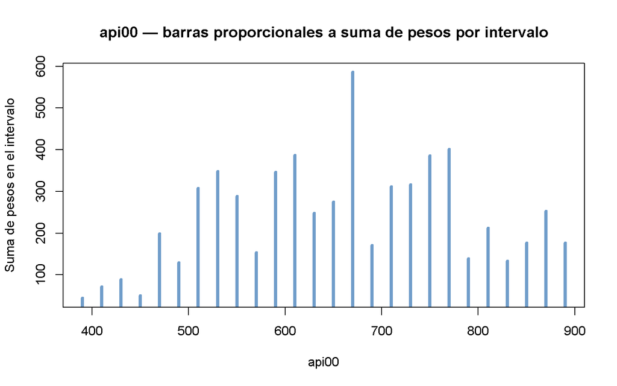

Histograma de api00 con barras reponderadas (ilustrativo; apistrat)

```r
w <- weights(dstrat)
br <- pretty(range(apistrat$api00), n = 20)
h0 <- hist(apistrat$api00, breaks = br, plot = FALSE)
counts_w <- numeric(length(h0$counts))
for (i in seq_along(h0$counts)) {
  lo <- h0$breaks[i]
  hi <- h0$breaks[i + 1]
  idx <- which(apistrat$api00 >= lo & (apistrat$api00 < hi | (i == length(h0$counts) & apistrat$api00 <= hi)))
  counts_w[i] <- if (length(idx)) sum(w[idx]) else 0
}
plot(h0$mids, counts_w, type = "h", lwd = 4, col = rgb(0.2, 0.45, 0.7, 0.7),
     main = "api00 — barras proporcionales a suma de pesos por intervalo",
     xlab = "api00", ylab = "Suma de pesos en el intervalo")
```

**Nota metodológica:** el histograma ponderado es una aproximación didáctica sumando pesos por intervalos; para inferencia formal sobre densidad use bootstrap de encuesta o funciones especializadas de `survey` si están disponibles en su versión.

# 11 Integración y discusión

Los resultados de las **siete fases** enlazan dos líneas de evidencia: **Saber 11** (Colombia) para muestreo (I), experimentación observacional (II–V) y PPS a nivel de estrato (VI), y **`apistrat`** para el estándar de **encuesta compleja** (VII), alineado con el criterio NHANES/ECV del proyecto expandido.

**Conexión Fase III → Fases IV y V:** el diseño factorial de Fase III identifica qué factores son activos. Las Fases IV–V profundizan con la codificación $\{-1, +1\}$ del $2^3$, permitiendo calcular contrastes, efectos principales e interacciones de forma sistemática y explorar la confusión ABC–bloque como herramienta de eficiencia experimental.

**Fases VI y VII — muestreo avanzado:** la Fase VI demuestra que el PPS reduce drásticamente la varianza del estimador cuando la variable de tamaño está correlacionada con la respuesta. La Fase VII generaliza este principio a un diseño complejo completo (estratos + pesos + fpc + deff), mostrando que ignorar el diseño produce errores estándar incorrectos — en `apistrat` el SE ingenuo subestima el SE real, lo que llevaría a ICs artificialmente estrechos e inferencias más optimistas de lo justificado.

# 12 Conclusiones

1. Se diseñó e implementó un plan de **muestreo aleatorio estratificado** por estrato socioeconómico con afijación proporcional a los $N_h$ del marco en la API; el tamaño calculado fue $n =$ 841 y la muestra efectiva tras descarga y limpieza fue **456** estudiantes (piloto de 300 observaciones para $S^2$, con $S^2 =$ 1968.5), con margen de error de ±3 puntos al 95% de confianza.
2. La estimación del puntaje global promedio mediante el paquete `survey` fue de 252.4 puntos, con un intervalo de confianza al 95% dentro del margen de error establecido en el diseño.
3. El **DBCA** con naturaleza del colegio como tratamiento y jornada como bloque detectó diferencias estadísticamente significativas en el puntaje global entre colegios oficiales y no oficiales (p < 0.05). Los colegios no oficiales obtienen puntajes promedio superiores, diferencia confirmada por la prueba de Tukey HSD.
4. La inclusión de la jornada como bloque estuvo justificada: su efecto resultó significativo, lo que indica que controlarlo mejoró la precisión del análisis.
5. Los supuestos del modelo (normalidad, homocedasticidad e independencia) fueron evaluados. Dado el tamaño de muestra, el ANOVA es robusto a desviaciones menores de normalidad por el Teorema Central del Límite.
6. En la **Fase III** se modeló el puntaje global con factores naturaleza, jornada y calendario (donde aplica), con énfasis en la **interacción** naturaleza × jornada y en residuos del modelo factorial.
7. La **Fase IV** construyó un **$2^3$** a partir de variables Saber codificadas como factores A, B y C, con análisis sobre medias por celda, **gráfica de Daniel** y un umbral simplificado tipo **Lenth** para efectos principales e interacciones.
8. La **Fase V** ilustró **confusión** de la interacción triple **ABC** con **bloques** sobre el mismo esquema agregado, alineado con la lógica de fracciones y bloqueo de Montgomery.
9. La **Fase VI** comparó, por simulación, la dispersión del estimador bajo **MAS de estratos** ($n=4$) frente a **PPS** con $\pi_h$ proporcionales a $N_h$ y estimación compatible con **Horvitz–Thompson**.
10. La **Fase VII** documentó inferencia bajo **diseño complejo** con `apistrat` (medias, intervalos, **deff**, cuantiles y visualización ponderada), como contraste con un análisis ingenuo sin pesos.

# 13 Declaración de uso de inteligencia artificial

En el desarrollo de este proyecto se utilizó **Claude (Anthropic)** como herramienta de asistencia en las siguientes etapas:

- **Exploración inicial:** Claude sugirió la fuente de datos (ICFES - datos.gov.co) y el enfoque metodológico general (muestreo estratificado + DBCA).
- **Código R:** Algunas secciones del código fueron generadas con asistencia de Claude (y, en la extensión a las fases III–VII, con asistencia de Cursor) y posteriormente revisadas, adaptadas y verificadas por el equipo.
- **Diagnóstico de datos:** Claude ayudó a identificar el problema de desbalance en el calendario académico y propuso la solución de usar jornada como bloque.
- **Fases III–VII:** Se incorporaron bloques metodológicos (factorial, $2^3$, bloques confundidos, PPS y encuesta compleja) con apoyo de herramientas de IA, contrastados con Lohr (2022) y Montgomery (2017).

**Validación crítica:** El equipo verificó cada decisión metodológica contrastándola con los módulos del curso y la bibliografía (Montgomery, 2017; Lohr, 2022). Se identificaron las siguientes limitaciones del asistente de IA: tendencia a sugerir tamaños de muestra arbitrarios sin justificación estadística (inicialmente propuso n=5000 sin cálculo), y necesidad de ajuste cuando los datos revelaron desbalance en las variables de bloque.

El producto final refleja la comprensión y criterio del equipo, usando la IA como apoyo y no como sustituto del razonamiento estadístico propio.

# 14 Referencias

- Lohr, S. L. (2022). *Sampling: Design and Analysis* (3rd ed.). CRC Press.
- Montgomery, D. C. (2017). *Design and Analysis of Experiments* (9th ed.). Wiley.
- ICFES. (2023). *Resultados únicos Saber 11*. Datos Abiertos Colombia. https://www.datos.gov.co/resource/kgxf-xxbe
- R Core Team. (2024). *R: A Language and Environment for Statistical Computing*. R Foundation for Statistical Computing.
- Lumley, T. (2023). *survey: Analysis of Complex Survey Samples* (R package version 4.2).